# Module 1 Variable Selection and Regularization

Published

July 27, 2025

# 1 Package

```r
#install.packages("AmesHousing")
```

# 2 Data

1. Boston Housing Data
2. Chicago Housing Data,
3. Heart data
- **Boston Housing Data**

`crim`: per capita crime rate by town.

`zn`: proportion of residential land zoned for lots over 25,000 sq.ft.

`indus`: proportion of non-retail business acres per town.

`chas`: Charles River dummy variable (= 1 if tract bounds river; 0 otherwise).

`nox`: nitrogen oxides concentration (parts per 10 million).

`rm`: average number of rooms per dwelling.

`age`: proportion of owner-occupied units built prior to 1940.

`dis`: weighted mean of distances to five Boston employment centres.

`rad`: index of accessibility to radial highways.

`tax`: full-value property-tax rate per $10,000.

`ptratio`: pupil-teacher ratio by town.

`lstat`: lower status of the population (percent).

`medv`: median value of owner-occupied homes in $1000s.

```r
data("Boston") # from the MASS package
head(Boston)
```

```
     crim zn indus chas   nox    rm  age    dis rad tax ptratio  black lstat
1 0.00632 18  2.31    0 0.538 6.575 65.2 4.0900   1 296    15.3 396.90  4.98
2 0.02731  0  7.07    0 0.469 6.421 78.9 4.9671   2 242    17.8 396.90  9.14
3 0.02729  0  7.07    0 0.469 7.185 61.1 4.9671   2 242    17.8 392.83  4.03
4 0.03237  0  2.18    0 0.458 6.998 45.8 6.0622   3 222    18.7 394.63  2.94
5 0.06905  0  2.18    0 0.458 7.147 54.2 6.0622   3 222    18.7 396.90  5.33
6 0.02985  0  2.18    0 0.458 6.430 58.7 6.0622   3 222    18.7 394.12  5.21
  medv
1 24.0
2 21.6
3 34.7
4 33.4
5 36.2
6 28.7
```

```r
skimr::skim(Boston)
```

Data summary

| Name | Boston |
| --- | --- |
| Number of rows | 506 |
| Number of columns | 14 |
| _______________________ |  |
| Column type frequency: |  |
| numeric | 14 |
| ________________________ |  |
| Group variables | None |

**Variable type: numeric**

| skim_variable | n_missing | complete_rate | mean | sd | p0 | p25 | p50 | p75 | p100 | hist |
| --- | --- | --- | --- | --- | --- | --- | --- | --- | --- | --- |
| crim | 0 | 1 | 3.61 | 8.60 | 0.01 | 0.08 | 0.26 | 3.68 | 88.98 | ▇▁▁▁▁ |
| zn | 0 | 1 | 11.36 | 23.32 | 0.00 | 0.00 | 0.00 | 12.50 | 100.00 | ▇▁▁▁▁ |
| indus | 0 | 1 | 11.14 | 6.86 | 0.46 | 5.19 | 9.69 | 18.10 | 27.74 | ▇▆▁▇▁ |
| chas | 0 | 1 | 0.07 | 0.25 | 0.00 | 0.00 | 0.00 | 0.00 | 1.00 | ▇▁▁▁▁ |
| nox | 0 | 1 | 0.55 | 0.12 | 0.38 | 0.45 | 0.54 | 0.62 | 0.87 | ▇▇▆▅▁ |
| rm | 0 | 1 | 6.28 | 0.70 | 3.56 | 5.89 | 6.21 | 6.62 | 8.78 | ▁▂▇▂▁ |
| age | 0 | 1 | 68.57 | 28.15 | 2.90 | 45.02 | 77.50 | 94.07 | 100.00 | ▂▂▂▃▇ |
| dis | 0 | 1 | 3.80 | 2.11 | 1.13 | 2.10 | 3.21 | 5.19 | 12.13 | ▇▅▂▁▁ |
| rad | 0 | 1 | 9.55 | 8.71 | 1.00 | 4.00 | 5.00 | 24.00 | 24.00 | ▇▂▁▁▃ |
| tax | 0 | 1 | 408.24 | 168.54 | 187.00 | 279.00 | 330.00 | 666.00 | 711.00 | ▇▇▃▁▇ |
| ptratio | 0 | 1 | 18.46 | 2.16 | 12.60 | 17.40 | 19.05 | 20.20 | 22.00 | ▁▃▅▅▇ |
| black | 0 | 1 | 356.67 | 91.29 | 0.32 | 375.38 | 391.44 | 396.22 | 396.90 | ▁▁▁▁▇ |
| lstat | 0 | 1 | 12.65 | 7.14 | 1.73 | 6.95 | 11.36 | 16.96 | 37.97 | ▇▇▅▂▁ |
| medv | 0 | 1 | 22.53 | 9.20 | 5.00 | 17.02 | 21.20 | 25.00 | 50.00 | ▂▇▅▁▁ |

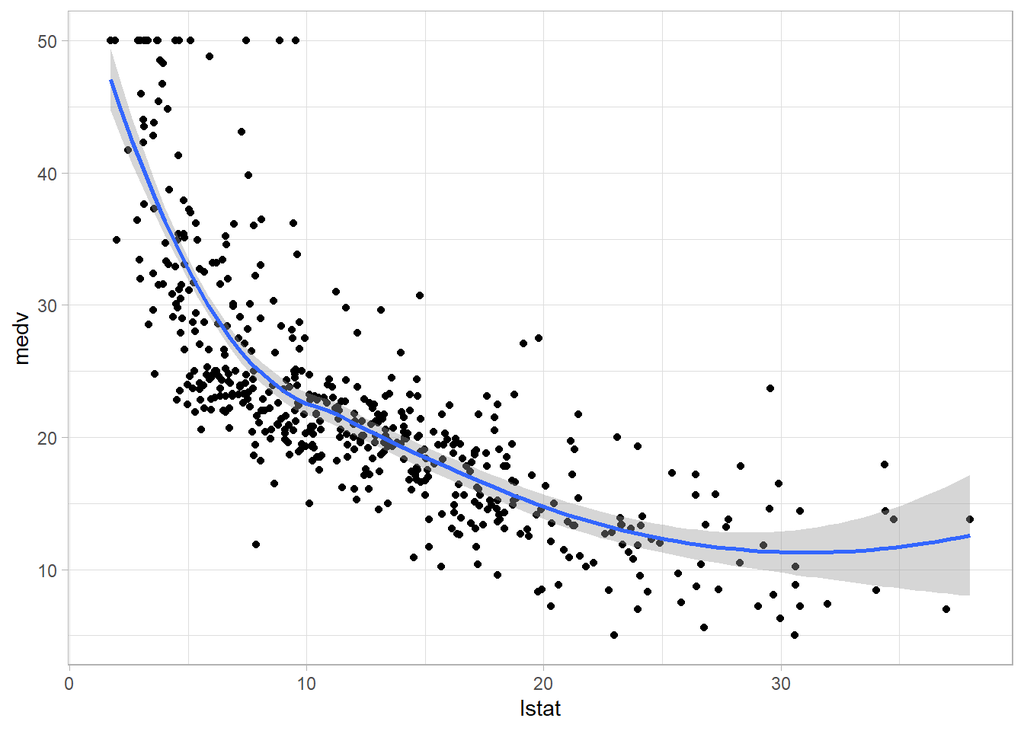

```r
# Can visualize few relationships
ggplot(data = Boston, mapping=aes(x=lstat, y=medv)) + #lstat= lower status of the population (percent). medv = median value of owner-occupied homes in $1000s.
  geom_point () +
  geom_smooth(method="loess")
```

```r
# Chicago Housing Data
chicago <-  read.csv(here("data", "chicago housingdata.csv"))
head(chicago)
```

```
  Ln_Price DSALE BEDROOM  Ln_SQFT Ln_LotSize CENTRALAIR BRICK GARAGE FIREPLACE
1 11.83138     0       3 6.794587   8.031060          0     0      2         0
2 11.28978     1       3 6.992096   8.039157          0     1      0         0
3 12.80902     0       5 7.047517   8.300529          1     1      2         0
4 12.45293     1       3 7.310550   8.499844          0     1      2         0
5 13.48909     0       4 7.664816   7.783224          1     1      2         1
6 12.08391     0       4 7.238497   8.383662          0     1      1         1
  BASE_FIN MASONRY PUBOPEN MICHLAKE LAKE_RIVER METRA_DIST RAIL_DIST
1        1       0       0        0          0    1.49801   0.20677
2        1       0       1        0          0    3.05638   0.19410
3        0       1       0        0          0    2.13873   0.85084
4        1       1       0        0          0    1.87168   1.03969
5        0       1       1        0          0    0.86320   0.05104
6        1       0       0        0          0    0.87661   0.39791
```

```r
here()
```

```
[1] "C:/Users/jmjung/OneDrive - Cal Poly Pomona/Documents/Work/Jaemin/4. Teaching/IBM6540/Lecture/ml"
```

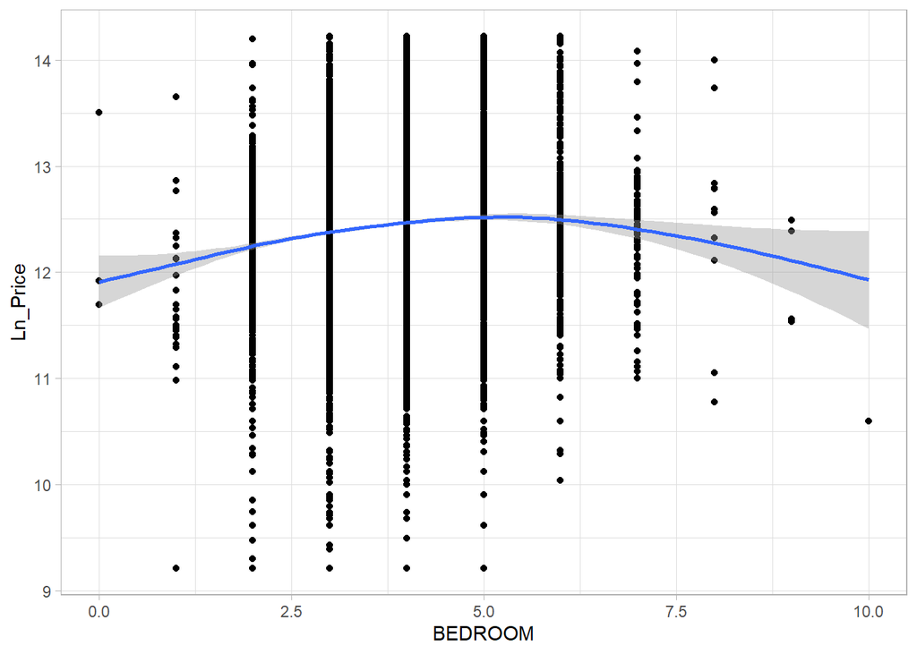

```r
ggplot(chicago,aes(x=BEDROOM, y=Ln_Price)) +
  geom_point () +
  geom_smooth(method="gam")
```

```r
# Heart Data
heart  <-  read_sav(here("data", "Heart Data.sav"))
head(heart)
```

```
# A tibble: 6 × 8
    Age Sex        ChestPain            RestBP  Chol   Fbs RestECG           CHD
  <dbl> <dbl+lbl>  <dbl+lbl>             <dbl> <dbl> <dbl> <dbl+lbl>       <dbl>
1    63 1 [Male]   1 [typical angina]      145   233     1 2 [left ventri…     0
2    67 1 [Male]   4 [asymptomatic]        160   286     0 2 [left ventri…     1
3    67 1 [Male]   4 [asymptomatic]        120   229     0 2 [left ventri…     1
4    37 1 [Male]   3 [non‐anginal pain]    130   250     0 0 [normal]          0
5    41 0 [Female] 2 [atypical angina]     130   204     0 2 [left ventri…     0
6    56 1 [Male]   2 [atypical angina]     120   236     0 0 [normal]          0
```

# 3 Multiple Linear and Logistic Regression

## 3.1 Log-Level Model with Boston Data

```r
# Boston Data
library(broom)

lm(log(medv) ~ ., data=Boston) |>
  tidy() |>
  mutate(across(where(is.numeric), ~ round(., 4)))
```

```
# A tibble: 14 × 5
   term        estimate std.error statistic p.value
   <chr>          <dbl>     <dbl>     <dbl>   <dbl>
 1 (Intercept)   4.10      0.204     20.1    0
 2 crim         -0.0103    0.0013    -7.81   0
 3 zn            0.0012    0.0005     2.13   0.0333
 4 indus         0.0025    0.0025     1.00   0.317
 5 chas          0.101     0.0345     2.93   0.0036
 6 nox          -0.778     0.153     -5.09   0
 7 rm            0.0908    0.0167     5.43   0
 8 age           0.0002    0.0005     0.398  0.691
 9 dis          -0.0491    0.008     -6.15   0
10 rad           0.0143    0.0027     5.37   0
11 tax          -0.0006    0.0002    -4.16   0
12 ptratio      -0.0383    0.0052    -7.31   0
13 black         0.0004    0.0001     3.85   0.0001
14 lstat        -0.029     0.002    -14.3    0
```

```r
# Interpretation: DV is log transformed: log-linear model
# possible to use margins if quadratic and interactions are in model
```

**Tip**

Log Linear model

- log(y) = β₀ + β₁x₁ + β₂x₂ + … + ε
  - A **one-unit increase in `xᵢ`** is associated with an **approximately (100 × βᵢ)% change in `y`**, **holding other variables constant**.

## 3.2 Log-Log Model with Chicago Data

```r
# Chicago Housing Data
lm(Ln_Price ~ ., data=chicago) %>%
  tidy() %>%
  round_df(4)
```

```
# A tibble: 16 × 5
   term        estimate std.error statistic p.value
   <chr>          <dbl>     <dbl>     <dbl>   <dbl>
 1 (Intercept)   9.45      0.167     56.6    0
 2 DSALE        -0.403     0.0138   -29.2    0
 3 BEDROOM      -0.0123    0.0045    -2.73   0.0064
 4 Ln_SQFT       0.470     0.0144    32.7    0
 5 Ln_LotSize   -0.0797    0.0172    -4.64   0
 6 CENTRALAIR    0.272     0.0094    28.8    0
 7 BRICK         0.0098    0.0119     0.823  0.410
 8 GARAGE        0.102     0.0056    18.4    0
 9 FIREPLACE     0.162     0.0073    22.3    0
10 BASE_FIN     -0.0041    0.0087    -0.478  0.633
11 MASONRY       0.0367    0.0114     3.22   0.0013
12 PUBOPEN       0.0187    0.0102     1.82   0.068
13 MICHLAKE      0.137     0.0248     5.53   0
14 LAKE_RIVER    0.0567    0.0239     2.37   0.0178
15 METRA_DIST   -0.0946    0.0044   -21.6    0
16 RAIL_DIST     0.193     0.0154    12.5    0
```

```r
# Interpretation: DV is log transformed and few IV's are also log transformed
```

**Tip**

- log(y) = β₀ + β₁log(x₁) + β₂x₂ + … + ε
  - A **1 % increase in `x1`** is associated with an **approximately β1% change in `y`**, **holding other variables constant**.

## 3.3 Functional Forms Summary Table

| Transformation | Interpretation |
| --- | --- |
| `log(y) ~ x` | 1 unit ↑ in `x` → ~100xβ% ↑ in `y` |
| `log(y) ~ log(x)` | 1% ↑ in `x` → β% ↑ in `y` (**elasticity**) |
| `y ~ log(x)` | 1% ↑ in `x` → `β/100` unit ↑ in `y` |
| `y ~ x` | 1 unit ↑ in `x` → β unit ↑ in `y` |

### 3.3.1 Caveat for log-level model

log(y) = 0.5·x + …

- In the Log-level model, it is only accurate when β is small (say |β| < 0.1). For larger coefficients, the exponential form gives the exact percentage change.
  - Approximate method: → 1 unit ↑ in x → **50%** ↑ in y (because 100 × 0.5)
  - Exact method: → 1 unit ↑ in x → (exp(0.5) – 1) × 100% ≈ **64.87%** increase in y

```r
(exp(0.1) - 1) * 100
```

```
[1] 10.51709
```

```r
(exp(0.5) - 1) * 100
```

```
[1] 64.87213
```

## 3.4 Logistic model with Heart Data

```r
# Running binary logistic model for heart
m3 <- glm(CHD ~ ., family = binomial(link="logit"), data=heart) #CHD (coronary heart disease: 1= yes, 0= no)
tidy(m3) %>%
  round_df(4)
```

```
# A tibble: 8 × 5
  term        estimate std.error statistic p.value
  <chr>          <dbl>     <dbl>     <dbl>   <dbl>
1 (Intercept) -12.0       1.77      -6.77   0
2 Age           0.0548    0.0178     3.07   0.0021
3 Sex           1.94      0.349      5.54   0
4 ChestPain     1.14      0.171      6.67   0
5 RestBP        0.0201    0.0084     2.40   0.0163
6 Chol          0.0036    0.0028     1.31   0.191
7 Fbs          -0.145     0.393     -0.369  0.712
8 RestECG       0.263     0.145      1.81   0.0699
```

```r
# You can calculate OR and their confidence intervals for interpretation
cbind(OR = coef(m3), confint(m3)) |>
  exp() |>
  round(3)
```

```
               OR 2.5 % 97.5 %
(Intercept) 0.000 0.000  0.000
Age         1.056 1.021  1.095
Sex         6.925 3.572 14.118
ChestPain   3.127 2.268  4.440
RestBP      1.020 1.004  1.038
Chol        1.004 0.998  1.009
Fbs         0.865 0.399  1.872
RestECG     1.301 0.980  1.733
```

## 3.5 Best Subset: Boston and Chicago Housing Data

### 3.5.1 Boston Data

```r
# Boston Housing Data : Best Subsets Regression
best.sub.1 = regsubsets(log(medv) ~ ., data = Boston, nvmax=10)
# regsubsets: Model selection by exhaustive search, forward or backward stepwise, or sequential replacement
# nvmax =   maximum size of subsets to examine

summary(best.sub.1)
```

```
Subset selection object
Call: regsubsets.formula(log(medv) ~ ., data = Boston, nvmax = 10)
13 Variables  (and intercept)
        Forced in Forced out
crim        FALSE      FALSE
zn          FALSE      FALSE
indus       FALSE      FALSE
chas        FALSE      FALSE
nox         FALSE      FALSE
rm          FALSE      FALSE
age         FALSE      FALSE
dis         FALSE      FALSE
rad         FALSE      FALSE
tax         FALSE      FALSE
ptratio     FALSE      FALSE
black       FALSE      FALSE
lstat       FALSE      FALSE
1 subsets of each size up to 10
Selection Algorithm: exhaustive
          crim zn  indus chas nox rm  age dis rad tax ptratio black lstat
1  ( 1 )  " "  " " " "   " "  " " " " " " " " " " " " " "     " "   "*"
2  ( 1 )  " "  " " " "   " "  " " " " " " " " " " " " "*"     " "   "*"
3  ( 1 )  "*"  " " " "   " "  " " " " " " " " " " " " "*"     " "   "*"
4  ( 1 )  "*"  " " " "   " "  " " "*" " " " " " " " " "*"     " "   "*"
5  ( 1 )  "*"  " " " "   " "  " " "*" " " "*" " " " " "*"     " "   "*"
6  ( 1 )  "*"  " " " "   " "  "*" "*" " " "*" " " " " "*"     " "   "*"
7  ( 1 )  "*"  " " " "   " "  "*" "*" " " "*" " " " " "*"     "*"   "*"
8  ( 1 )  "*"  " " " "   " "  "*" "*" " " "*" "*" "*" "*"     " "   "*"
9  ( 1 )  "*"  " " " "   " "  "*" "*" " " "*" "*" "*" "*"     "*"   "*"
10  ( 1 ) "*"  " " " "   "*"  "*" "*" " " "*" "*" "*" "*"     "*"   "*"
```

```r
reg.summary <- summary(best.sub.1)
reg.summary$rsq
```

```
 [1] 0.6480799 0.6948709 0.7177671 0.7426593 0.7505194 0.7650280 0.7708418
 [8] 0.7764742 0.7834085 0.7874240
```

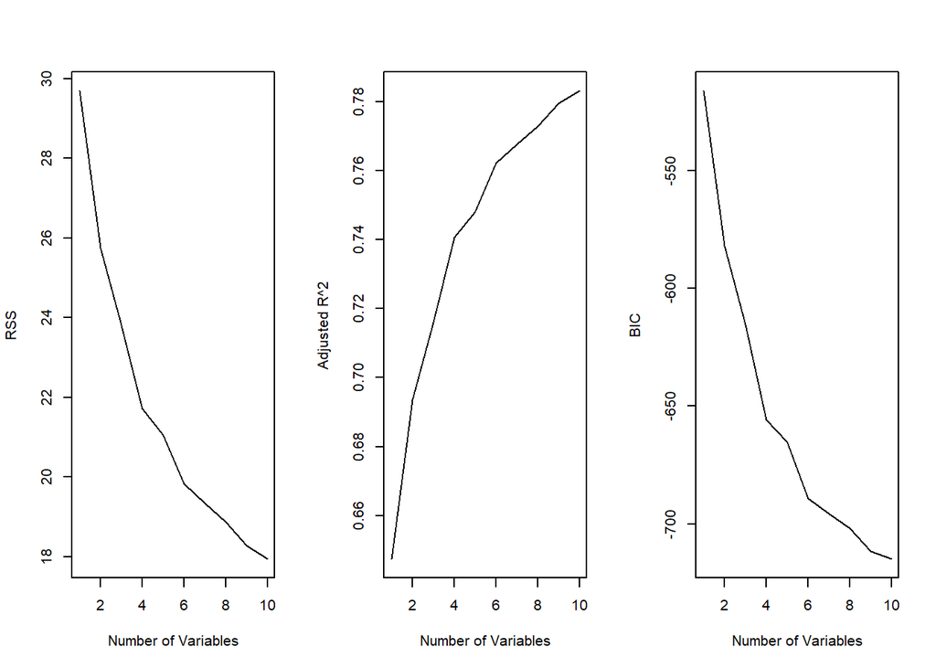

```r
par(mfrow=c(1,3)) # par can be used to set or query graphical parameters. Parameters can be set by specifying them as arguments to par in tag = value form, or by passing them as a list of tagged values.
plot(reg.summary$rss, xlab='Number of Variables', ylab='RSS', type='l') # rss = residual sum of squares
plot(reg.summary$adjr2, xlab='Number of Variables', ylab='Adjusted R^2', type='l')
plot(reg.summary$bic, xlab='Number of Variables', ylab='BIC', type='l')
```

### 3.5.2 Chicago Housing data

```r
# Chicagor Housing Data : Best Subsets Regression
best.sub.1 = regsubsets(Ln_Price ~ ., data = chicago, nvmax=10)

summary(best.sub.1)
```

```
Subset selection object
Call: regsubsets.formula(Ln_Price ~ ., data = chicago, nvmax = 10)
15 Variables  (and intercept)
           Forced in Forced out
DSALE          FALSE      FALSE
BEDROOM        FALSE      FALSE
Ln_SQFT        FALSE      FALSE
Ln_LotSize     FALSE      FALSE
CENTRALAIR     FALSE      FALSE
BRICK          FALSE      FALSE
GARAGE         FALSE      FALSE
FIREPLACE      FALSE      FALSE
BASE_FIN       FALSE      FALSE
MASONRY        FALSE      FALSE
PUBOPEN        FALSE      FALSE
MICHLAKE       FALSE      FALSE
LAKE_RIVER     FALSE      FALSE
METRA_DIST     FALSE      FALSE
RAIL_DIST      FALSE      FALSE
1 subsets of each size up to 10
Selection Algorithm: exhaustive
          DSALE BEDROOM Ln_SQFT Ln_LotSize CENTRALAIR BRICK GARAGE FIREPLACE
1  ( 1 )  " "   " "     "*"     " "        " "        " "   " "    " "
2  ( 1 )  " "   " "     "*"     " "        "*"        " "   " "    " "
3  ( 1 )  "*"   " "     "*"     " "        "*"        " "   " "    " "
4  ( 1 )  "*"   " "     "*"     " "        "*"        " "   " "    "*"
5  ( 1 )  "*"   " "     "*"     " "        "*"        " "   " "    "*"
6  ( 1 )  "*"   " "     "*"     " "        "*"        " "   "*"    "*"
7  ( 1 )  "*"   " "     "*"     " "        "*"        " "   "*"    "*"
8  ( 1 )  "*"   " "     "*"     " "        "*"        " "   "*"    "*"
9  ( 1 )  "*"   " "     "*"     " "        "*"        " "   "*"    "*"
10  ( 1 ) "*"   " "     "*"     "*"        "*"        " "   "*"    "*"
          BASE_FIN MASONRY PUBOPEN MICHLAKE LAKE_RIVER METRA_DIST RAIL_DIST
1  ( 1 )  " "      " "     " "     " "      " "        " "        " "
2  ( 1 )  " "      " "     " "     " "      " "        " "        " "
3  ( 1 )  " "      " "     " "     " "      " "        " "        " "
4  ( 1 )  " "      " "     " "     " "      " "        " "        " "
5  ( 1 )  " "      " "     " "     " "      " "        "*"        " "
6  ( 1 )  " "      " "     " "     " "      " "        "*"        " "
7  ( 1 )  " "      " "     " "     " "      " "        "*"        "*"
8  ( 1 )  " "      " "     " "     "*"      " "        "*"        "*"
9  ( 1 )  " "      "*"     " "     "*"      " "        "*"        "*"
10  ( 1 ) " "      "*"     " "     "*"      " "        "*"        "*"
```

```r
reg.summary <- summary(best.sub.1)
reg.summary$rsq
```

```
 [1] 0.2286302 0.3248952 0.3672191 0.3915345 0.4133501 0.4275003 0.4335615
 [8] 0.4348900 0.4358524 0.4368142
```

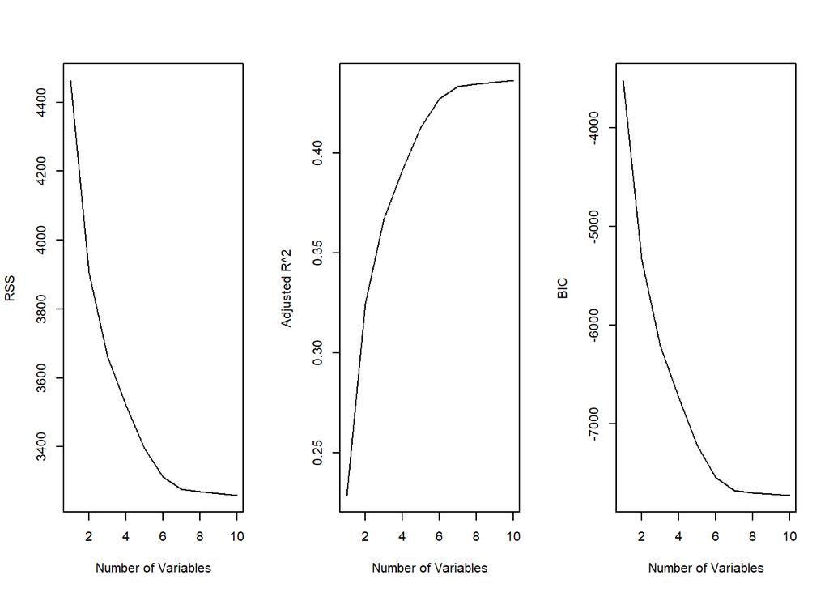

```r
par(mfrow=c(1,3))
plot(reg.summary$rss, xlab='Number of Variables', ylab='RSS', type='l')
plot(reg.summary$adjr2, xlab='Number of Variables', ylab='Adjusted R^2', type='l')
plot(reg.summary$bic, xlab='Number of Variables', ylab='BIC', type='l')
```

# 4 MARS - Multivariate Adaptive Regression Splines:

## 4.1 MARS with Boston Data

```r
# Sample splitting into Train and Test

set.seed(2022)
index <- sample(1:nrow(Boston), size = floor(0.7*nrow(Boston)), replace = FALSE) #floor is from Round() wherein ceiling takes a single numeric argument x and returns a numeric vector containing the smallest integers not less than the corresponding elements of x.
train <- Boston[index,]
test <- Boston[-index,]
dim(train)
```

```
[1] 354  14
```

```r
dim(test)
```

```
[1] 152  14
```

```r
dim(Boston)
```

```
[1] 506  14
```

```r
#?earth #package for MARS
# x, y, degree and nprune (number of terms or basis function)
x <- train[, -14]
y <- train[, 14]
dim(x)
```

```
[1] 354  13
```

```r
dim(y)
```

```r
y |> as_tibble() |> dim()
```

```
[1] 354   1
```

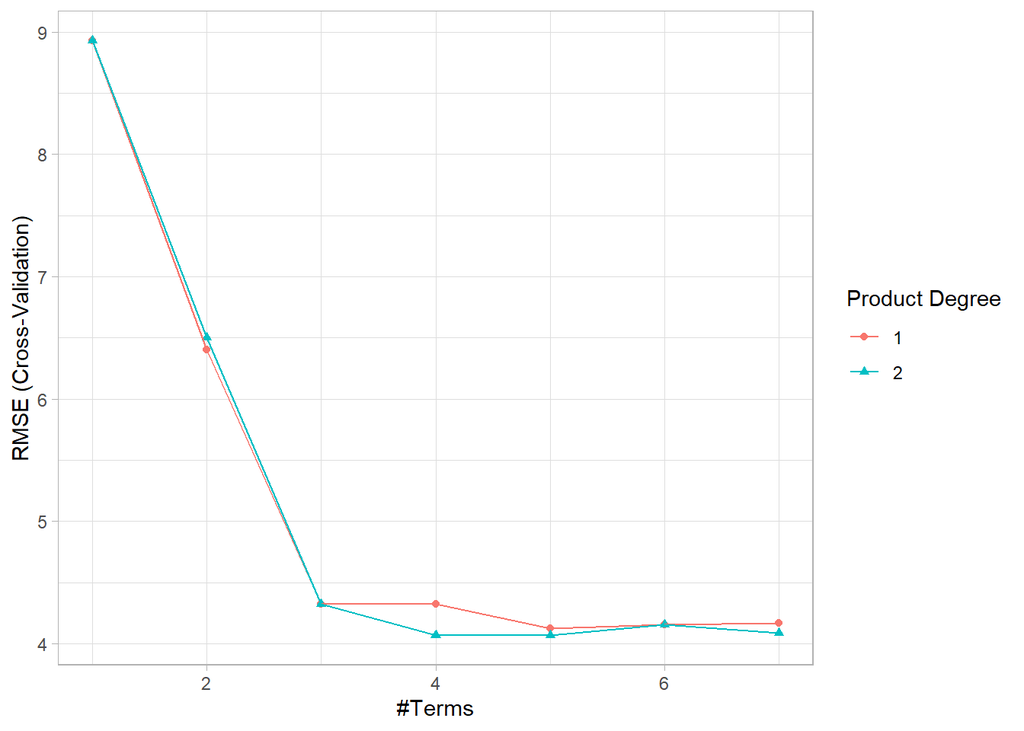

```r
# Create parameter tuning grid
parameter_grid <- floor(expand.grid(degree = 1:2, nprune = seq(2:8)))
?expand.grid # Create a data frame from all combinations of the supplied vectors or factors.
# view(parameter_grid)

# Perform cross-validation using caret package
cv_mars_boston <- caret::train(x=x, y=y,
                        method ='earth',
                        metric='RMSE',
                        trControl = trainControl(method='cv', number = 10),
                        tuneGrid=parameter_grid)
ggplot(cv_mars_boston)
```

```r
cv_mars_boston
```

```
Multivariate Adaptive Regression Spline

354 samples
 13 predictor

No pre-processing
Resampling: Cross-Validated (10 fold)
Summary of sample sizes: 319, 318, 319, 318, 319, 318, ...
Resampling results across tuning parameters:

  degree  nprune  RMSE      Rsquared   MAE
  1       1       8.928037        NaN  6.586560
  1       2       6.400469  0.5312001  4.604826
  1       3       4.320590  0.7783405  3.048010
  1       4       4.324631  0.7714221  3.058073
  1       5       4.121767  0.7859647  2.915968
  1       6       4.155589  0.7794324  2.918073
  1       7       4.168854  0.7774770  2.898571
  2       1       8.928037        NaN  6.586560
  2       2       6.499477  0.5160813  4.727533
  2       3       4.322035  0.7785039  3.016896
  2       4       4.065808  0.7926417  2.775977
  2       5       4.065880  0.7907359  2.793328
  2       6       4.155269  0.7782562  2.836112
  2       7       4.084708  0.7850459  2.808703

RMSE was used to select the optimal model using the smallest value.
The final values used for the model were nprune = 4 and degree = 2.
```

```r
mars_predict <- predict(object=cv_mars_boston$finalModel,
                        newdata = test)
mars_predict
```

```
               y
  [1,] 22.418247
  [2,]  9.070439
  [3,] 17.307686
  [4,] 18.200108
  [5,] 22.983233
  [6,] 24.061844
  [7,] 14.790928
  [8,] 19.407125
  [9,] 16.267597
 [10,] 18.777936
 [11,] 17.192121
 [12,] 24.080306
 [13,] 22.071551
 [14,] 24.447062
```

[output cut: 138 more lines]

```r
mean(abs(test$medv - mars_predict))
```

```
[1] 3.582523
```

```r
# Multivariate Adaptive Regression Splines
mars.1 <-  earth(medv ~ ., degree=1, nprune = 5, data=Boston) #nprune: maximum no. of terms including intercept.
summary(mars.1)
```

```
Call: earth(formula=medv~., data=Boston, degree=1, nprune=5)

                coefficients
(Intercept)       26.2175309
h(rm-6.431)        8.3739605
h(ptratio-14.7)   -0.6260660
h(6.12-lstat)      2.6469864
h(lstat-6.12)     -0.5536614

Selected 5 of 24 terms, and 3 of 13 predictors (nprune=5)
Termination condition: Reached nk 27
Importance: rm, lstat, ptratio, crim-unused, zn-unused, indus-unused, ...
Number of terms at each degree of interaction: 1 4 (additive model)
GCV 18.75408    RSS 9154.991    GRSq 0.778724    RSq 0.7856792
```

```
 plotmo grid:    crim zn indus chas   nox     rm  age     dis rad tax ptratio
              0.25651  0  9.69    0 0.538 6.2085 77.5 3.20745   5 330   19.05
  black lstat
 391.44 11.36
```

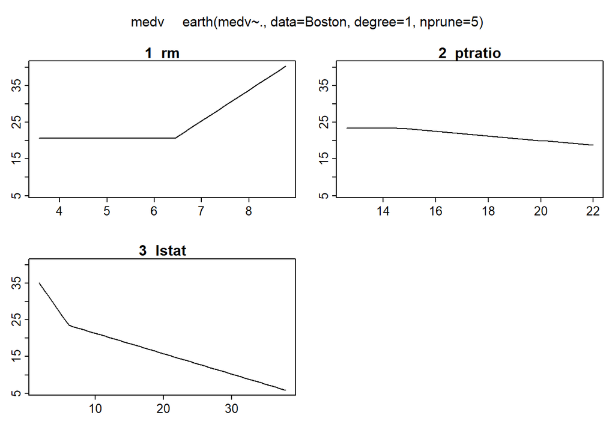

```r
plotmo(mars.1) # out of 13 variables, only 3 were picked.
```

```r
mars.2 <-  earth(log(medv) ~ ., degree=1, nprune = 7, data=Boston)
summary(mars.2)
```

```
Call: earth(formula=log(medv)~., data=Boston, degree=1, nprune=7)

                coefficients
(Intercept)       2.79856060
h(23.6482-crim)   0.01912623
h(nox-0.624)     -0.48348593
h(rm-6.405)       0.33815948
h(1.4165-dis)     2.76852577
h(ptratio-18.6)  -0.06002929
h(lstat-6.12)    -0.02619073

Selected 7 of 24 terms, and 6 of 13 predictors (nprune=7)
Termination condition: Reached nk 27
Importance: lstat, rm, crim, dis, ptratio, nox, zn-unused, indus-unused, ...
Number of terms at each degree of interaction: 1 6 (additive model)
GCV 0.03325566    RSS 15.97382    GRSq 0.8013556    RSq 0.810684
```

```
 plotmo grid:    crim zn indus chas   nox     rm  age     dis rad tax ptratio
              0.25651  0  9.69    0 0.538 6.2085 77.5 3.20745   5 330   19.05
  black lstat
 391.44 11.36
```

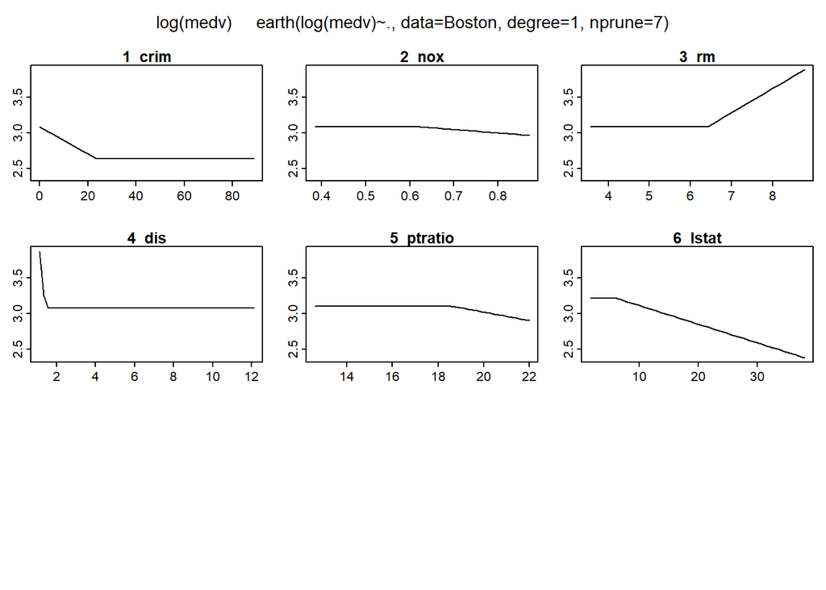

```r
plotmo(mars.2)
```

## 4.2 MARS with Chicago Housing Data

```r
dim(chicago)
```

```
[1] 13641    16
```

```r
set.seed(2022)

index <- sample(1:nrow(chicago), size = floor(0.7*nrow(chicago)),replace = FALSE)
train <- chicago[index,]
test <- chicago[-index,]
dim(train)
```

```
[1] 9548   16
```

```r
dim(test)
```

```
[1] 4093   16
```

```r
head(train)
```

```
      Ln_Price DSALE BEDROOM  Ln_SQFT Ln_LotSize CENTRALAIR BRICK GARAGE
4324  12.14950     0       3 6.827629   8.229511          1     0      2
9651  12.34583     0       4 7.961370   8.732305          0     0      0
7886  12.38631     0       4 7.338888   8.055158          1     0      2
2871  12.54254     0       4 7.016610   8.213382          1     1      2
12107 11.53273     0       4 7.342132   8.047190          0     1      2
8900  12.34583     0       5 6.742881   8.237479          1     1      2
      FIREPLACE BASE_FIN MASONRY PUBOPEN MICHLAKE LAKE_RIVER METRA_DIST
4324          0        0       1       0        0          0    0.65439
9651          0        0       0       0        0          0    2.31907
7886          0        0       0       0        0          0    3.86844
2871          0        0       1       1        0          0    1.15361
12107         0        1       1       0        0          0    1.75289
8900          0        0       1       0        0          0    3.28619
      RAIL_DIST
4324    0.11980
9651    0.05874
7886    0.09365
2871    0.91218
12107   0.12768
8900    0.61539
```

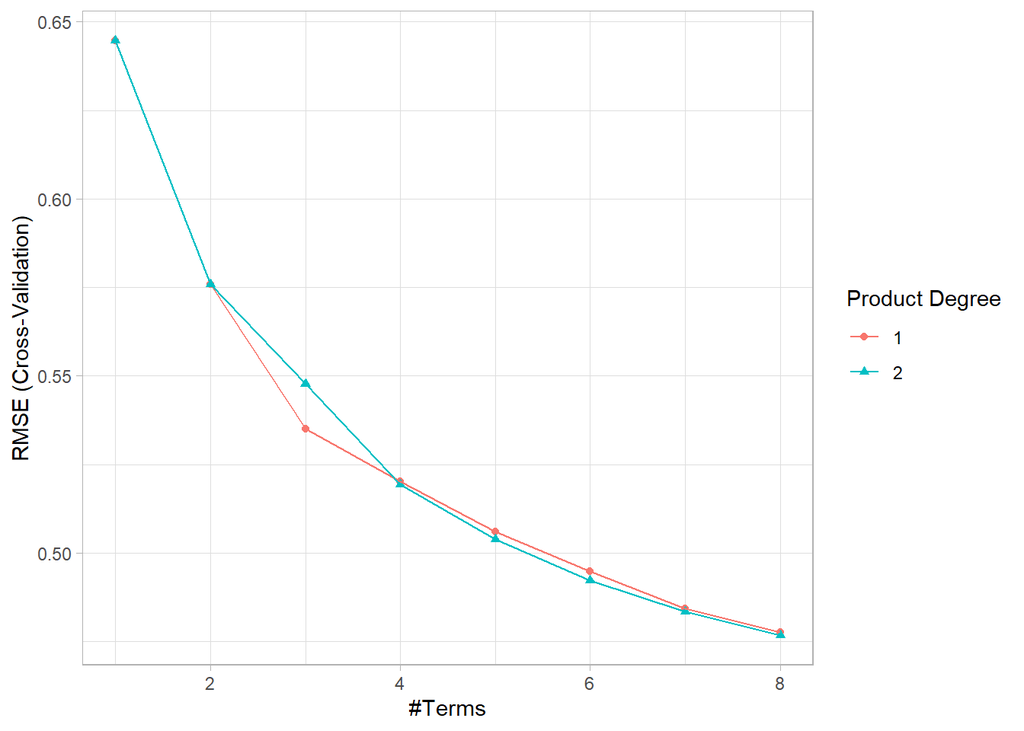

```r
# ?earth
# x, y, degree and nprune
x <- train[,-1]
y <- train[,1]

# Create parameter tuning grid
parameter_grid <- floor(expand.grid(degree = 1:2, nprune = seq(2:9)))
# view(parameter_grid)

# Perform cross-validation
cv_mars_chicago <- train(x=x, y=y,
                        method ='earth',
                        metric='RMSE',
                        trControl = trainControl(method='cv', number = 10),
                        tuneGrid=parameter_grid)
ggplot(cv_mars_chicago)
```

```r
cv_mars_chicago
```

```
Multivariate Adaptive Regression Spline

9548 samples
  15 predictor

No pre-processing
Resampling: Cross-Validated (10 fold)
Summary of sample sizes: 8594, 8593, 8593, 8593, 8595, 8593, ...
Resampling results across tuning parameters:

  degree  nprune  RMSE       Rsquared   MAE
  1       1       0.6446611        NaN  0.4728620
  1       2       0.5759693  0.2032215  0.4306636
  1       3       0.5350618  0.3125292  0.3944259
  1       4       0.5202096  0.3499586  0.3812916
  1       5       0.5060970  0.3845149  0.3694546
  1       6       0.4947973  0.4114378  0.3572004
  1       7       0.4842178  0.4364123  0.3495319
  1       8       0.4776711  0.4515217  0.3430419
  2       1       0.6446611        NaN  0.4728620
  2       2       0.5759693  0.2032215  0.4306636
  2       3       0.5477529  0.2794736  0.4063493
  2       4       0.5194159  0.3517969  0.3823886
  2       5       0.5037993  0.3901437  0.3673946
  2       6       0.4922369  0.4174451  0.3551499
  2       7       0.4833962  0.4381339  0.3489126
  2       8       0.4767189  0.4536373  0.3419630

RMSE was used to select the optimal model using the smallest value.
The final values used for the model were nprune = 8 and degree = 2.
```

```r
# Multivariate Adaptive Regression Splines
mars.1 <-  earth(Ln_Price ~ ., degree=1, nprune = 9, data=chicago)
summary(mars.1)
```

```
Call: earth(formula=Ln_Price~., data=chicago, degree=1, nprune=9)

                      coefficients
(Intercept)             12.7899101
DSALE                   -0.3911041
CENTRALAIR               0.2566998
h(7.41397-Ln_SQFT)      -0.3631383
h(Ln_SQFT-7.41397)       0.7224153
h(1-GARAGE)             -0.2919811
h(2-FIREPLACE)          -0.1826014
h(METRA_DIST-0.78952)   -0.0994015
h(RAIL_DIST-0.52333)     0.3634155

Selected 9 of 21 terms, and 7 of 15 predictors (nprune=9)
Termination condition: RSq changed by less than 0.001 at 21 terms
Importance: Ln_SQFT, CENTRALAIR, DSALE, METRA_DIST, GARAGE, FIREPLACE, ...
Number of terms at each degree of interaction: 1 8 (additive model)
GCV 0.2352082    RSS 3200.484    GRSq 0.4455478    RSq 0.4468478
```

```
 plotmo grid:    DSALE BEDROOM  Ln_SQFT Ln_LotSize CENTRALAIR BRICK GARAGE
                     0       3 7.080026   8.229511          1     1      2
 FIREPLACE BASE_FIN MASONRY PUBOPEN MICHLAKE LAKE_RIVER METRA_DIST RAIL_DIST
         0        0       1       0        0          0    1.53462   0.28607
```

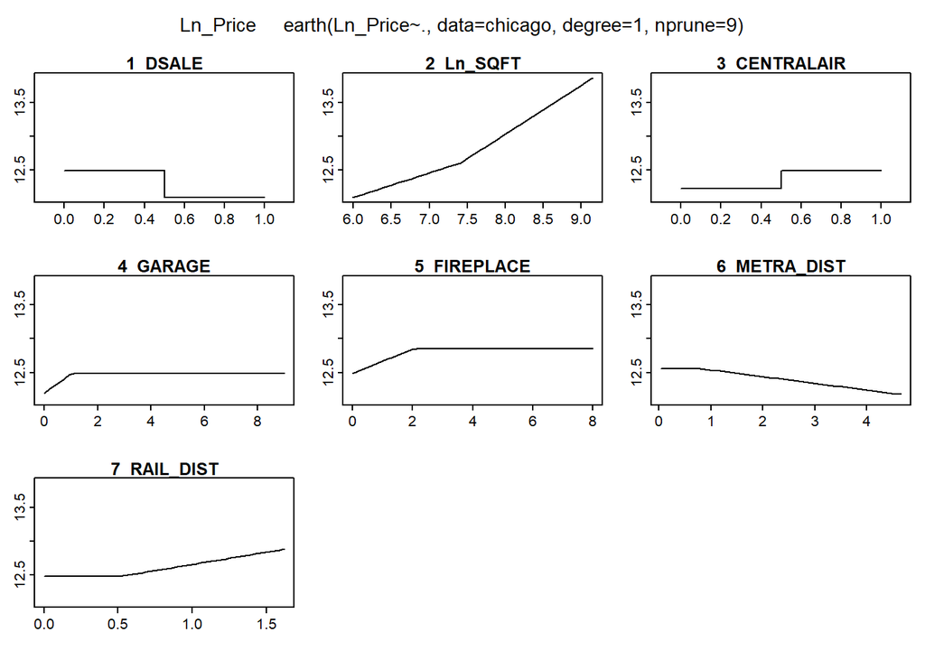

```r
plotmo(mars.1)
```

# 5 GAM: Generalized Additive Models

**Generalized Additive Models (GAM)**:

- Extended standard linear model by allowing non-linear functions of each of the variables, while maintaining additivity.
- Can be applied to both quatitative (i.e., regression) and nominal response variable (i.e. logistic regression)

## 5.1 GAM; Regression Model

not critical

```
Call: gam(formula = log(medv) ~ s(crim) + s(rm) + s(dis) + s(ptratio) +
    s(lstat), data = Boston)
Deviance Residuals:
      Min        1Q    Median        3Q       Max
-0.689414 -0.090606 -0.005989  0.087780  0.912012

(Dispersion Parameter for gaussian family taken to be 0.0324)

    Null Deviance: 84.3765 on 505 degrees of freedom
Residual Deviance: 15.725 on 484.9996 degrees of freedom
AIC: -276.5033

Number of Local Scoring Iterations: NA

Anova for Parametric Effects
            Df  Sum Sq Mean Sq F value    Pr(>F)
s(crim)      1 25.8737 25.8737 798.011 < 2.2e-16 ***
s(rm)        1 20.9302 20.9302 645.540 < 2.2e-16 ***
s(dis)       1  0.5191  0.5191  16.011 7.283e-05 ***
s(ptratio)   1  1.8794  1.8794  57.967 1.404e-13 ***
s(lstat)     1 11.3096 11.3096 348.817 < 2.2e-16 ***
Residuals  485 15.7250  0.0324
---
Signif. codes:  0 '***' 0.001 '**' 0.01 '*' 0.05 '.' 0.1 ' ' 1

Anova for Nonparametric Effects
            Npar Df  Npar F     Pr(F)
(Intercept)
s(crim)           3  4.1278  0.006603 **
s(rm)             3 27.9782 < 2.2e-16 ***
s(dis)            3  2.7640  0.041479 *
s(ptratio)        3  2.5208  0.057254 .
s(lstat)          3  9.4583 4.397e-06 ***
---
Signif. codes:  0 '***' 0.001 '**' 0.01 '*' 0.05 '.' 0.1 ' ' 1
```

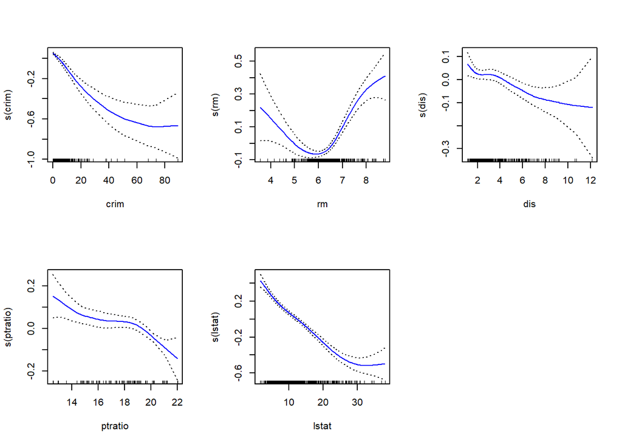

```r
# Regression Model

# You can quickly check the relationship: whether linear or non-linear

gam.1 = gam(log(medv)~ s(crim) + s(rm) + s(dis) + s(ptratio) + s(lstat), data=Boston) # s(): Defining smooths in GAM formulae: polynominal

par(mfrow=c(2,3))
plot(gam.1, se=TRUE, col="blue")
summary(gam.1)
```

**Summary**

```
Anova for Parametric Effects
            Df  Sum Sq Mean Sq F value    Pr(>F)
s(crim)      1 25.8737 25.8737 798.011 < 2.2e-16 ***
s(rm)        1 20.9302 20.9302 645.540 < 2.2e-16 ***
s(dis)       1  0.5191  0.5191  16.011 7.283e-05 ***
s(ptratio)   1  1.8794  1.8794  57.967 1.404e-13 ***
s(lstat)     1 11.3096 11.3096 348.817 < 2.2e-16 ***
Residuals  485 15.7250  0.0324
---
Signif. codes:  0 ‘***’ 0.001 ‘**’ 0.01 ‘*’ 0.05 ‘.’ 0.1 ‘ ’ 1
```

- Tests if the non-linear effect is significant

```
Anova for Nonparametric Effects
            Npar Df  Npar F     Pr(F)
(Intercept)
s(crim)           3  4.1278  0.006603 **
s(rm)             3 27.9782 < 2.2e-16 ***
s(dis)            3  2.7640  0.041479 *
s(ptratio)        3  2.5208  0.057254 .
s(lstat)          3  9.4583 4.397e-06 ***
---
Signif. codes:  0 ‘***’ 0.001 ‘**’ 0.01 ‘*’ 0.05 ‘.’ 0.1 ‘ ’ 1
```

## 5.2 GAM; Classification Model (Your turn):

Heart Data, Classification

```r
# Classification model

gam2 = gam(I(CHD)~ Age + Sex + ChestPain + RestBP + Chol + RestECG, family = binomial, data=heart)
summary(gam2)
```

```
Call: gam(formula = I(CHD) ~ Age + Sex + ChestPain + RestBP + Chol +
    RestECG, family = binomial, data = heart)
Deviance Residuals:
    Min      1Q  Median      3Q     Max
-2.3255 -0.7866 -0.2523  0.7993  2.6964

(Dispersion Parameter for binomial family taken to be 1)

    Null Deviance: 417.9821 on 302 degrees of freedom
Residual Deviance: 303.2601 on 296 degrees of freedom
AIC: 317.2601

Number of Local Scoring Iterations: 4

Anova for Parametric Effects
           Df Sum Sq Mean Sq F value    Pr(>F)
Age         1   4.35   4.353  3.7891 0.0525320 .
Sex         1  14.62  14.619 12.7247 0.0004207 ***
ChestPain   1  38.77  38.771 33.7471 1.619e-08 ***
RestBP      1   6.36   6.359  5.5349 0.0192953 *
Chol        1   2.52   2.519  2.1925 0.1397482
RestECG     1   3.24   3.241  2.8215 0.0940665 .
Residuals 296 340.07   1.149
---
Signif. codes:  0 '***' 0.001 '**' 0.01 '*' 0.05 '.' 0.1 ' ' 1
```

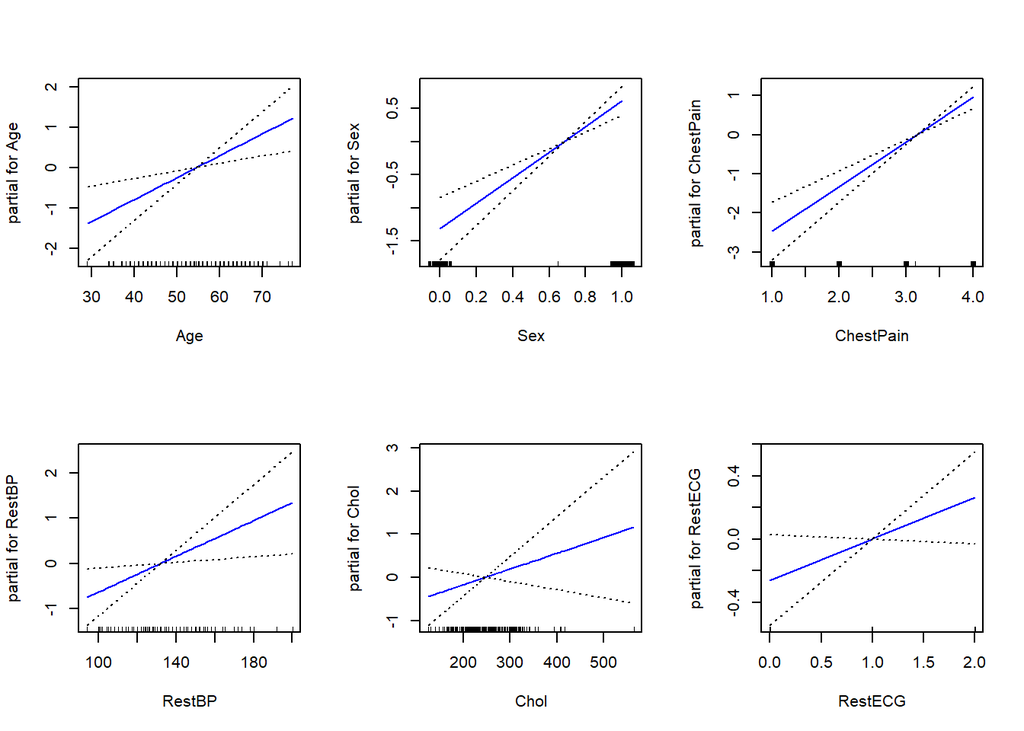

```r
par(mfrow=c(2,3))
plot(gam2, se=TRUE, col="blue")
```

```r
gam3 = gam(I(CHD)~ s(Age) + Sex + ChestPain + s(RestBP) + s(Chol) + RestECG, family = binomial, data=heart)
summary(gam3)
```

```
Call: gam(formula = I(CHD) ~ s(Age) + Sex + ChestPain + s(RestBP) +
    s(Chol) + RestECG, family = binomial, data = heart)
Deviance Residuals:
    Min      1Q  Median      3Q     Max
-2.2750 -0.7433 -0.2344  0.8172  2.6108

(Dispersion Parameter for binomial family taken to be 1)

    Null Deviance: 417.9821 on 302 degrees of freedom
Residual Deviance: 285.9778 on 287.0008 degrees of freedom
AIC: 317.9762

Number of Local Scoring Iterations: NA

Anova for Parametric Effects
           Df  Sum Sq Mean Sq F value    Pr(>F)
s(Age)      1   5.674   5.674  5.1581 0.0238787 *
Sex         1  14.566  14.566 13.2419 0.0003246 ***
ChestPain   1  39.298  39.298 35.7254 6.725e-09 ***
s(RestBP)   1   3.869   3.869  3.5172 0.0617509 .
s(Chol)     1   2.800   2.800  2.5451 0.1117406
RestECG     1   3.407   3.407  3.0974 0.0794846 .
Residuals 287 315.699   1.100
---
Signif. codes:  0 '***' 0.001 '**' 0.01 '*' 0.05 '.' 0.1 ' ' 1

Anova for Nonparametric Effects
            Npar Df Npar Chisq P(Chi)
(Intercept)
s(Age)            3    10.1161 0.0176 *
Sex
ChestPain
s(RestBP)         3     3.0865 0.3784
s(Chol)           3     3.3098 0.3462
RestECG
---
Signif. codes:  0 '***' 0.001 '**' 0.01 '*' 0.05 '.' 0.1 ' ' 1
```

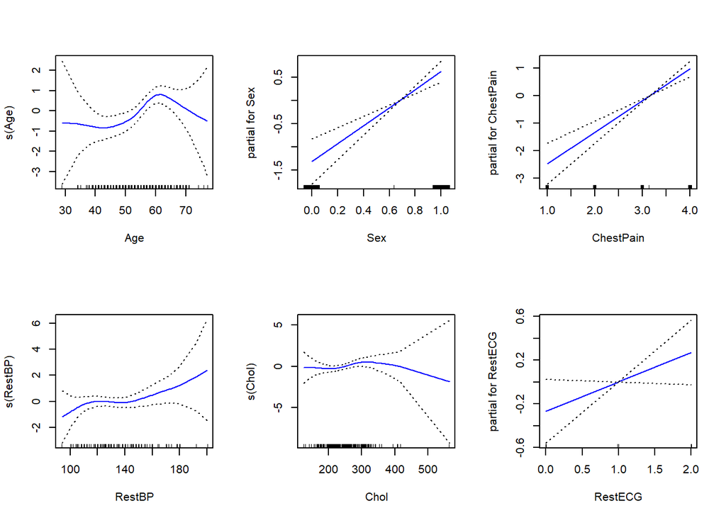

```r
par(mfrow=c(2,3))
plot(gam3, se=TRUE, col="blue")
```

```r
anova(gam2, gam3, test ="Chisq")
```

```
Analysis of Deviance Table

Model 1: I(CHD) ~ Age + Sex + ChestPain + RestBP + Chol + RestECG
Model 2: I(CHD) ~ s(Age) + Sex + ChestPain + s(RestBP) + s(Chol) + RestECG
  Resid. Df Resid. Dev     Df Deviance Pr(>Chi)
1       296     303.26
2       287     285.98 8.9992   17.282  0.04446 *
---
Signif. codes:  0 '***' 0.001 '**' 0.01 '*' 0.05 '.' 0.1 ' ' 1
```

```r
# BIC
BIC(gam2)
```

```
[1] 343.2563
```

```r
BIC(gam3)
```

```
[1] 343.9723
```

# 6 Regularization:

## 6.1 Lasso & Ridge using glmnet with crime data

```r
data <-  read.csv(here("data", "crime.csv"))
dim(data)
```

```
[1] 1994   96
```

```r
head(data)
```

```
  population householdsize racepctblack racePctWhite racePctAsian racePctHisp
1       0.19          0.33         0.02         0.90         0.12        0.17
2       0.00          0.16         0.12         0.74         0.45        0.07
3       0.00          0.42         0.49         0.56         0.17        0.04
4       0.04          0.77         1.00         0.08         0.12        0.10
5       0.01          0.55         0.02         0.95         0.09        0.05
6       0.02          0.28         0.06         0.54         1.00        0.25
  agePct12t21 agePct12t29 agePct16t24 agePct65up numbUrban pctUrban medIncome
1        0.34        0.47        0.29       0.32      0.20      1.0      0.37
2        0.26        0.59        0.35       0.27      0.02      1.0      0.31
3        0.39        0.47        0.28       0.32      0.00      0.0      0.30
4        0.51        0.50        0.34       0.21      0.06      1.0      0.58
5        0.38        0.38        0.23       0.36      0.02      0.9      0.50
6        0.31        0.48        0.27       0.37      0.04      1.0      0.52
  pctWWage pctWFarmSelf pctWInvInc pctWSocSec pctWPubAsst pctWRetire medFamInc
```

[output cut: 118 more lines]

```r
skimr::skim(data)
```

Data summary

| Name | data |
| --- | --- |
| Number of rows | 1994 |
| Number of columns | 96 |
| _______________________ |  |
| Column type frequency: |  |
| numeric | 96 |
| ________________________ |  |
| Group variables | None |

**Variable type: numeric**

| skim_variable | n_missing | complete_rate | mean | sd | p0 | p25 | p50 | p75 | p100 | hist |
| --- | --- | --- | --- | --- | --- | --- | --- | --- | --- | --- |
| population | 0 | 1 | 0.06 | 0.13 | 0 | 0.01 | 0.02 | 0.05 | 1 | ▇▁▁▁▁ |
| householdsize | 0 | 1 | 0.46 | 0.16 | 0 | 0.35 | 0.44 | 0.54 | 1 | ▁▇▇▂▁ |
| racepctblack | 0 | 1 | 0.18 | 0.25 | 0 | 0.02 | 0.06 | 0.23 | 1 | ▇▁▁▁▁ |
| racePctWhite | 0 | 1 | 0.75 | 0.24 | 0 | 0.63 | 0.85 | 0.94 | 1 | ▁▁▂▃▇ |
| racePctAsian | 0 | 1 | 0.15 | 0.21 | 0 | 0.04 | 0.07 | 0.17 | 1 | ▇▁▁▁▁ |
| racePctHisp | 0 | 1 | 0.14 | 0.23 | 0 | 0.01 | 0.04 | 0.16 | 1 | ▇▁▁▁▁ |
| agePct12t21 | 0 | 1 | 0.42 | 0.16 | 0 | 0.34 | 0.40 | 0.47 | 1 | ▁▇▆▁▁ |
| agePct12t29 | 0 | 1 | 0.49 | 0.14 | 0 | 0.41 | 0.48 | 0.54 | 1 | ▁▃▇▁▁ |
| agePct16t24 | 0 | 1 | 0.34 | 0.17 | 0 | 0.25 | 0.29 | 0.36 | 1 | ▁▇▁▁▁ |
| agePct65up | 0 | 1 | 0.42 | 0.18 | 0 | 0.30 | 0.42 | 0.53 | 1 | ▂▇▇▂▁ |
| numbUrban | 0 | 1 | 0.06 | 0.13 | 0 | 0.00 | 0.03 | 0.07 | 1 | ▇▁▁▁▁ |
| pctUrban | 0 | 1 | 0.70 | 0.44 | 0 | 0.00 | 1.00 | 1.00 | 1 | ▃▁▁▁▇ |
| medIncome | 0 | 1 | 0.36 | 0.21 | 0 | 0.20 | 0.32 | 0.49 | 1 | ▆▇▅▂▁ |
| pctWWage | 0 | 1 | 0.56 | 0.18 | 0 | 0.44 | 0.56 | 0.69 | 1 | ▁▃▇▆▂ |
| pctWFarmSelf | 0 | 1 | 0.29 | 0.20 | 0 | 0.16 | 0.23 | 0.37 | 1 | ▇▇▂▁▁ |
| pctWInvInc | 0 | 1 | 0.50 | 0.18 | 0 | 0.37 | 0.48 | 0.62 | 1 | ▁▆▇▅▁ |
| pctWSocSec | 0 | 1 | 0.47 | 0.17 | 0 | 0.35 | 0.48 | 0.58 | 1 | ▁▅▇▃▁ |
| pctWPubAsst | 0 | 1 | 0.32 | 0.22 | 0 | 0.14 | 0.26 | 0.44 | 1 | ▇▇▃▂▁ |
| pctWRetire | 0 | 1 | 0.48 | 0.17 | 0 | 0.36 | 0.47 | 0.58 | 1 | ▁▆▇▃▁ |
| medFamInc | 0 | 1 | 0.38 | 0.20 | 0 | 0.23 | 0.33 | 0.48 | 1 | ▃▇▅▂▁ |
| perCapInc | 0 | 1 | 0.35 | 0.19 | 0 | 0.22 | 0.30 | 0.43 | 1 | ▃▇▃▁▁ |
| whitePerCap | 0 | 1 | 0.37 | 0.19 | 0 | 0.24 | 0.32 | 0.44 | 1 | ▂▇▃▁▁ |
| blackPerCap | 0 | 1 | 0.29 | 0.17 | 0 | 0.17 | 0.25 | 0.38 | 1 | ▇▇▃▁▁ |
| indianPerCap | 0 | 1 | 0.20 | 0.16 | 0 | 0.11 | 0.17 | 0.25 | 1 | ▇▃▁▁▁ |
| AsianPerCap | 0 | 1 | 0.32 | 0.20 | 0 | 0.19 | 0.28 | 0.40 | 1 | ▅▇▂▁▁ |
| HispPerCap | 0 | 1 | 0.39 | 0.18 | 0 | 0.26 | 0.34 | 0.48 | 1 | ▂▇▅▁▁ |
| NumUnderPov | 0 | 1 | 0.06 | 0.13 | 0 | 0.01 | 0.02 | 0.05 | 1 | ▇▁▁▁▁ |
| PctPopUnderPov | 0 | 1 | 0.30 | 0.23 | 0 | 0.11 | 0.25 | 0.45 | 1 | ▇▅▃▁▁ |
| PctLess9thGrade | 0 | 1 | 0.32 | 0.21 | 0 | 0.16 | 0.27 | 0.42 | 1 | ▇▇▃▁▁ |
| PctNotHSGrad | 0 | 1 | 0.38 | 0.20 | 0 | 0.23 | 0.36 | 0.51 | 1 | ▅▇▆▂▁ |

[output cut: 66 more lines]

```r
#separate x and y
xdata <-  model.matrix(ViolentCrimesPerPop ~ ., data)[,-1] # model.matrix creates a design (or model) matrix, e.g., by expanding factors to a set of dummy variables (depending on the contrasts) and expanding interactions similarly. [,-1]: take out y variable

dim(xdata)
```

```
[1] 1994   95
```

```r
head(xdata)
```

```
  population householdsize racepctblack racePctWhite racePctAsian racePctHisp
1       0.19          0.33         0.02         0.90         0.12        0.17
2       0.00          0.16         0.12         0.74         0.45        0.07
3       0.00          0.42         0.49         0.56         0.17        0.04
4       0.04          0.77         1.00         0.08         0.12        0.10
5       0.01          0.55         0.02         0.95         0.09        0.05
6       0.02          0.28         0.06         0.54         1.00        0.25
  agePct12t21 agePct12t29 agePct16t24 agePct65up numbUrban pctUrban medIncome
1        0.34        0.47        0.29       0.32      0.20      1.0      0.37
2        0.26        0.59        0.35       0.27      0.02      1.0      0.31
3        0.39        0.47        0.28       0.32      0.00      0.0      0.30
4        0.51        0.50        0.34       0.21      0.06      1.0      0.58
5        0.38        0.38        0.23       0.36      0.02      0.9      0.50
6        0.31        0.48        0.27       0.37      0.04      1.0      0.52
  pctWWage pctWFarmSelf pctWInvInc pctWSocSec pctWPubAsst pctWRetire medFamInc
```

[output cut: 111 more lines]

```r
names(xdata)
```

```r
skimr::skim(xdata)
```

Data summary

| Name | xdata |
| --- | --- |
| Number of rows | 1994 |
| Number of columns | 95 |
| _______________________ |  |
| Column type frequency: |  |
| numeric | 95 |
| ________________________ |  |
| Group variables | None |

**Variable type: numeric**

| skim_variable | n_missing | complete_rate | mean | sd | p0 | p25 | p50 | p75 | p100 | hist |
| --- | --- | --- | --- | --- | --- | --- | --- | --- | --- | --- |
| population | 0 | 1 | 0.06 | 0.13 | 0 | 0.01 | 0.02 | 0.05 | 1 | ▇▁▁▁▁ |
| householdsize | 0 | 1 | 0.46 | 0.16 | 0 | 0.35 | 0.44 | 0.54 | 1 | ▁▇▇▂▁ |
| racepctblack | 0 | 1 | 0.18 | 0.25 | 0 | 0.02 | 0.06 | 0.23 | 1 | ▇▁▁▁▁ |
| racePctWhite | 0 | 1 | 0.75 | 0.24 | 0 | 0.63 | 0.85 | 0.94 | 1 | ▁▁▂▃▇ |
| racePctAsian | 0 | 1 | 0.15 | 0.21 | 0 | 0.04 | 0.07 | 0.17 | 1 | ▇▁▁▁▁ |
| racePctHisp | 0 | 1 | 0.14 | 0.23 | 0 | 0.01 | 0.04 | 0.16 | 1 | ▇▁▁▁▁ |
| agePct12t21 | 0 | 1 | 0.42 | 0.16 | 0 | 0.34 | 0.40 | 0.47 | 1 | ▁▇▆▁▁ |
| agePct12t29 | 0 | 1 | 0.49 | 0.14 | 0 | 0.41 | 0.48 | 0.54 | 1 | ▁▃▇▁▁ |
| agePct16t24 | 0 | 1 | 0.34 | 0.17 | 0 | 0.25 | 0.29 | 0.36 | 1 | ▁▇▁▁▁ |
| agePct65up | 0 | 1 | 0.42 | 0.18 | 0 | 0.30 | 0.42 | 0.53 | 1 | ▂▇▇▂▁ |
| numbUrban | 0 | 1 | 0.06 | 0.13 | 0 | 0.00 | 0.03 | 0.07 | 1 | ▇▁▁▁▁ |
| pctUrban | 0 | 1 | 0.70 | 0.44 | 0 | 0.00 | 1.00 | 1.00 | 1 | ▃▁▁▁▇ |
| medIncome | 0 | 1 | 0.36 | 0.21 | 0 | 0.20 | 0.32 | 0.49 | 1 | ▆▇▅▂▁ |
| pctWWage | 0 | 1 | 0.56 | 0.18 | 0 | 0.44 | 0.56 | 0.69 | 1 | ▁▃▇▆▂ |
| pctWFarmSelf | 0 | 1 | 0.29 | 0.20 | 0 | 0.16 | 0.23 | 0.37 | 1 | ▇▇▂▁▁ |
| pctWInvInc | 0 | 1 | 0.50 | 0.18 | 0 | 0.37 | 0.48 | 0.62 | 1 | ▁▆▇▅▁ |
| pctWSocSec | 0 | 1 | 0.47 | 0.17 | 0 | 0.35 | 0.48 | 0.58 | 1 | ▁▅▇▃▁ |
| pctWPubAsst | 0 | 1 | 0.32 | 0.22 | 0 | 0.14 | 0.26 | 0.44 | 1 | ▇▇▃▂▁ |
| pctWRetire | 0 | 1 | 0.48 | 0.17 | 0 | 0.36 | 0.47 | 0.58 | 1 | ▁▆▇▃▁ |
| medFamInc | 0 | 1 | 0.38 | 0.20 | 0 | 0.23 | 0.33 | 0.48 | 1 | ▃▇▅▂▁ |
| perCapInc | 0 | 1 | 0.35 | 0.19 | 0 | 0.22 | 0.30 | 0.43 | 1 | ▃▇▃▁▁ |
| whitePerCap | 0 | 1 | 0.37 | 0.19 | 0 | 0.24 | 0.32 | 0.44 | 1 | ▂▇▃▁▁ |
| blackPerCap | 0 | 1 | 0.29 | 0.17 | 0 | 0.17 | 0.25 | 0.38 | 1 | ▇▇▃▁▁ |
| indianPerCap | 0 | 1 | 0.20 | 0.16 | 0 | 0.11 | 0.17 | 0.25 | 1 | ▇▃▁▁▁ |
| AsianPerCap | 0 | 1 | 0.32 | 0.20 | 0 | 0.19 | 0.28 | 0.40 | 1 | ▅▇▂▁▁ |
| HispPerCap | 0 | 1 | 0.39 | 0.18 | 0 | 0.26 | 0.34 | 0.48 | 1 | ▂▇▅▁▁ |
| NumUnderPov | 0 | 1 | 0.06 | 0.13 | 0 | 0.01 | 0.02 | 0.05 | 1 | ▇▁▁▁▁ |
| PctPopUnderPov | 0 | 1 | 0.30 | 0.23 | 0 | 0.11 | 0.25 | 0.45 | 1 | ▇▅▃▁▁ |
| PctLess9thGrade | 0 | 1 | 0.32 | 0.21 | 0 | 0.16 | 0.27 | 0.42 | 1 | ▇▇▃▁▁ |
| PctNotHSGrad | 0 | 1 | 0.38 | 0.20 | 0 | 0.23 | 0.36 | 0.51 | 1 | ▅▇▆▂▁ |

[output cut: 65 more lines]

```r
ydata <-  data$ViolentCrimesPerPop

# Random split of data
set.seed(340)
itrain <- sample(1:nrow(data), nrow(data)*0.5)
length(itrain)
```

```
[1] 997
```

```r
itest <- (-itrain)


#separate into training and test data
xtrain = xdata[itrain,]
ytrain = ydata[itrain]

xtest = xdata[itest,]
ytest = ydata[itest]
```

### 6.1.1 Fitting Lasso, alpha = 1 Crime Data

- Lasso regularization penalizes the size of coefficients, and the penalty strength is controlled by λ.
- High λ = stronger shrinkage → simpler model (more coefficients shrunk to 0).
- `cv.glmnet(...)` runs **Lasso regression** (`alpha = 1`) with 10-fold cross-validation.
- `type.measure = "mse"`: Uses **Mean Squared Error** as the evaluation metric.
- `standardize = TRUE` by default: Each predictor is standardized to mean 0 and sd 1 before fitting.

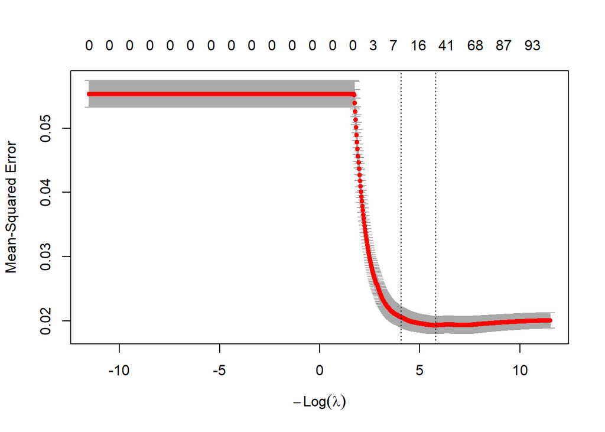

```r
# Step 1: Create a grid of λ (lambda) values
# By default glmnet uses lambda = 10^10 =10,000,000,000  and 10^-2 = 0.01
# present plots in log scale
grid = 10^seq(5,-5, length=1000) # grid,

# Step 2: Run 10-fold cross-validation to find optimal λ
set.seed(123)
cv.lasso = cv.glmnet(xtrain, ytrain, alpha=1, lambda=grid,
                     nfolds=10, type.measure = "mse")
# default setting is standardize = True

# Step 3: Plot the cross-validation results
par(mfrow=c(1,1))
plot(cv.lasso)
```

```r
cv.lasso
```

```
Call:  cv.glmnet(x = xtrain, y = ytrain, lambda = grid, type.measure = "mse",      nfolds = 10, alpha = 1)

Measure: Mean-Squared Error

      Lambda Index Measure       SE Nonzero
min 0.003037   752 0.01929 0.001298      29
1se 0.017109   677 0.02056 0.001316       9
```

```r
# Step 4: Extract optimal λ values
lambda1 <- cv.lasso$lambda.min # Best model (smallest MSE)
lambda2 <- cv.lasso$lambda.1se # Simpler model (within 1 SE of best)
lambda1
```

```
[1] 0.003037264
```

```r
lambda2
```

```
[1] 0.01710934
```

```r
# Step 5: Fit models at both λ values
fit.min <-  glmnet(xtrain, ytrain, alpha=1, lambda = lambda1)
coef(fit.min)
```

```
96 x 1 sparse Matrix of class "dgCMatrix"
                                 s0
(Intercept)            0.3756452441
population             .
householdsize          .
racepctblack           0.1707301978
racePctWhite          -0.0026736956
racePctAsian           0.0002313954
racePctHisp            .
agePct12t21            .
agePct12t29           -0.0424066909
agePct16t24            .
agePct65up             .
numbUrban              .
pctUrban               0.0268869305
medIncome              .
pctWWage               .
pctWFarmSelf           .
pctWInvInc            -0.0068436006
pctWSocSec             .
pctWPubAsst            .
pctWRetire            -0.0373391110
medFamInc              .
perCapInc              .
whitePerCap            .
blackPerCap            .
indianPerCap           .
AsianPerCap            0.0314251199
HispPerCap             0.0212006302
NumUnderPov            .
PctPopUnderPov         .
PctLess9thGrade        .
PctNotHSGrad           .
PctBSorMore            .
PctUnemployed         -0.0009488625
PctEmploy              .
PctEmplManu           -0.0246171403
PctEmplProfServ       -0.0074991468
PctOccupManu           .
PctOccupMgmtProf       .
```

[output cut: 43 more lines]

```
OwnOccHiQuart          .
RentLowQ               .
RentMedian             .
RentHighQ              .
MedRent                .
MedRentPctHousInc      0.0228360502
MedOwnCostPctInc       .
MedOwnCostPctIncNoMtg -0.0503016171
NumInShelters          .
NumStreet              0.1933436922
PctForeignBorn         0.0115602035
PctBornSameState       .
PctSameHouse85         .
PctSameCity85          .
PctSameState85         .
```

```r
fit.1se <-  glmnet(xtrain, ytrain, alpha=1, lambda = lambda2)
coef(fit.1se)
```

```
96 x 1 sparse Matrix of class "dgCMatrix"
                                s0
(Intercept)            0.499413884
population             .
householdsize          .
racepctblack           .
racePctWhite          -0.157911961
racePctAsian           .
racePctHisp            .
agePct12t21            .
agePct12t29            .
agePct16t24            .
agePct65up             .
numbUrban              .
pctUrban               .
medIncome              .
pctWWage               .
pctWFarmSelf           .
pctWInvInc             .
pctWSocSec             .
pctWPubAsst            .
pctWRetire             .
medFamInc              .
perCapInc              .
whitePerCap            .
blackPerCap            .
indianPerCap           .
AsianPerCap            .
HispPerCap             .
NumUnderPov            .
PctPopUnderPov         .
PctLess9thGrade        .
PctNotHSGrad           .
PctBSorMore            .
PctUnemployed          .
PctEmploy              .
PctEmplManu            .
PctEmplProfServ        .
PctOccupManu           .
PctOccupMgmtProf       .
```

[output cut: 43 more lines]

```
OwnOccHiQuart          .
RentLowQ               .
RentMedian             .
RentHighQ              .
MedRent                .
MedRentPctHousInc      .
MedOwnCostPctInc       .
MedOwnCostPctIncNoMtg  .
NumInShelters          .
NumStreet              0.111343309
PctForeignBorn         .
PctBornSameState       .
PctSameHouse85         .
PctSameCity85          .
PctSameState85         .
```

```r
# Step 6: Predict on test data and calculate MSE
lasso.yhat <-  predict(fit.min, s=lambda1, newx=xtest)
mean((lasso.yhat - ytest)^2)
```

```
[1] 0.01858083
```

```r
lasso.yhat <-  predict(fit.1se, s=lambda2, newx=xtest)
mean((lasso.yhat - ytest)^2)
```

```
[1] 0.01963288
```

```r
# Step 7: converting sparse matrix to matrix and to data frame
coef(fit.min) %>% as.matrix() %>% as.data.frame() %>%
  filter(s0 !=0)
```

```
                                 s0
(Intercept)            0.3756452441
racepctblack           0.1707301978
racePctWhite          -0.0026736956
racePctAsian           0.0002313954
agePct12t29           -0.0424066909
pctUrban               0.0268869305
pctWInvInc            -0.0068436006
pctWRetire            -0.0373391110
AsianPerCap            0.0314251199
HispPerCap             0.0212006302
PctUnemployed         -0.0009488625
PctEmplManu           -0.0246171403
PctEmplProfServ       -0.0074991468
MalePctDivorce         0.1021467891
PctKids2Par           -0.2688536543
PctYoungKids2Par      -0.0560370785
PctTeen2Par           -0.0005501856
PctWorkMom            -0.0586147833
PctIlleg               0.1732035295
PctImmigRecent        -0.0095886872
PctImmigRec5          -0.0032296016
PctPersDenseHous       0.1316357952
PctHousLess3BR         0.0242708413
HousVacant             0.1287967109
PctHousOccup          -0.0647283355
PctVacantBoarded       0.0303719750
PctVacMore6Mos        -0.0039144293
MedRentPctHousInc      0.0228360502
MedOwnCostPctIncNoMtg -0.0503016171
NumStreet              0.1933436922
PctForeignBorn         0.0115602035
```

```r
coef(fit.1se) %>% as.matrix() %>% as.data.frame() %>%
  filter(s0 !=0)
```

```
                           s0
(Intercept)       0.499413884
racePctWhite     -0.157911961
MalePctDivorce    0.059817043
PctKids2Par      -0.358851985
PctIlleg          0.178500681
PctPersDenseHous  0.029319988
HousVacant        0.160150267
PctHousOccup     -0.018619948
PctVacantBoarded  0.006644043
NumStreet         0.111343309
```

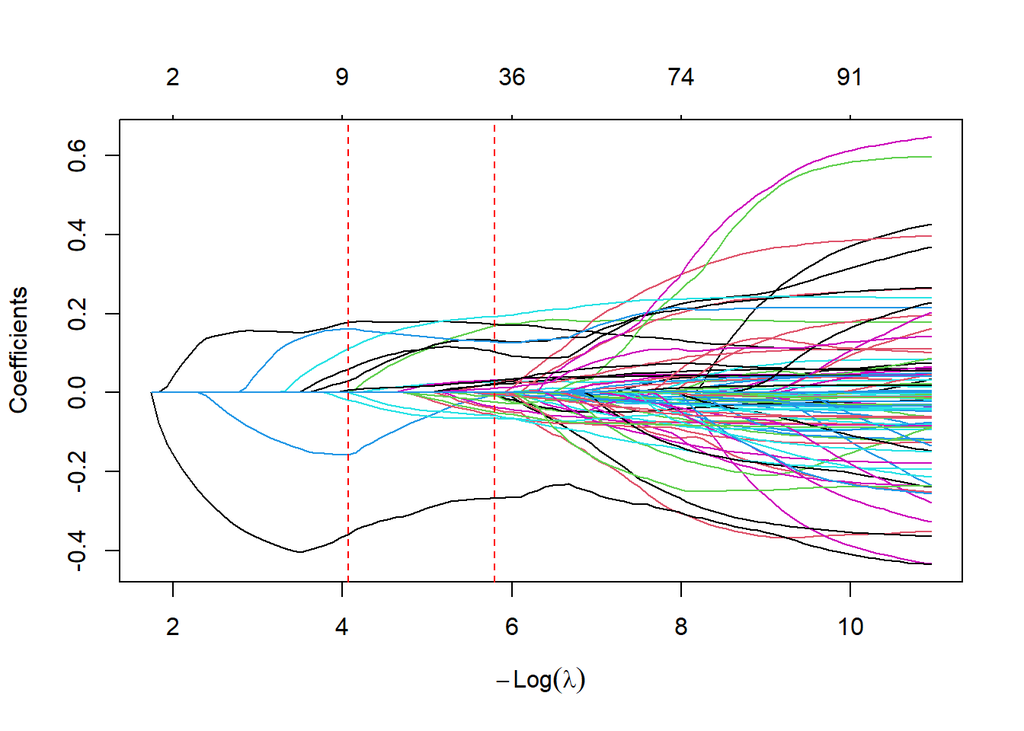

```r
# Step 8: Fit Lasso without cross-validation
cv.lasso_min <- glmnet(x=xtrain, y=ytrain, alpha=1)

plot(cv.lasso_min, xvar = "lambda")
abline(v = -log(cv.lasso$lambda.min), col = "red", lty = "dashed")
abline(v = -log(cv.lasso$lambda.1se), col = "red", lty = "dashed")
```

**Note**

| Function | Cross-validation? | Purpose |
| --- | --- | --- |
| `glmnet(...)` | ❌ No | Fits full Lasso path |
| `cv.glmnet(...)` | ✅ Yes | Finds optimal λ via CV |

### 6.1.2 Fitting Ridge, alpha = 0 Crime Data

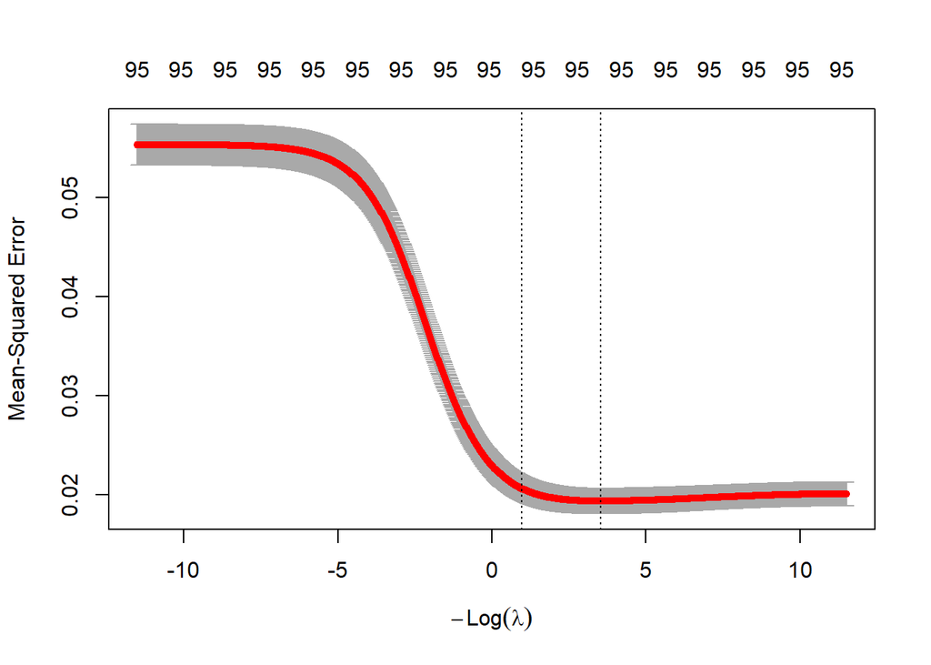

```r
# find lamda via cross validiation.

grid = 10^seq(5,-5, length=1000) # grid,
set.seed(123)
cv.ridge = cv.glmnet(xtrain, ytrain, alpha=0, lambda=grid,
                     nfolds=10, type.measure = "mse")
# alpha = 0  Ridge; default setting is standardize = True

plot(cv.ridge)
```

```r
cv.ridge
```

```
Call:  cv.glmnet(x = xtrain, y = ytrain, lambda = grid, type.measure = "mse",      nfolds = 10, alpha = 0)

Measure: Mean-Squared Error

    Lambda Index Measure       SE Nonzero
min 0.0291   654 0.01936 0.001264      95
1se 0.3755   543 0.02062 0.001251      95
```

```r
lambda1 <-  cv.ridge$lambda.min
lambda2 <- cv.ridge$lambda.1se
lambda1
```

```
[1] 0.02907123
```

```r
lambda2
```

```
[1] 0.3754694
```

```r
# run glmnet using the lambda.

fit.min <-  glmnet(xtrain, ytrain, alpha=0, lambda=lambda1)
coef(fit.min)
```

```
96 x 1 sparse Matrix of class "dgCMatrix"
                                 s0
(Intercept)            0.5152860285
population            -0.0005301389
householdsize          0.0250003190
racepctblack           0.1219415134
racePctWhite          -0.0734296456
racePctAsian          -0.0034446962
racePctHisp           -0.0211712088
agePct12t21            0.0008117498
agePct12t29           -0.0917160350
agePct16t24           -0.0164386282
agePct65up             0.0145344196
numbUrban             -0.0008741815
pctUrban               0.0285451078
medIncome             -0.0068409266
pctWWage              -0.0567077932
pctWFarmSelf           0.0065278220
pctWInvInc            -0.0629555449
pctWSocSec             0.0257891300
pctWPubAsst            0.0076469469
pctWRetire            -0.0650635597
medFamInc             -0.0087634143
perCapInc             -0.0240078789
whitePerCap           -0.0001332230
blackPerCap           -0.0293536903
indianPerCap          -0.0171927861
AsianPerCap            0.0409722837
HispPerCap             0.0422155357
NumUnderPov            0.0285874165
PctPopUnderPov        -0.0173964008
PctLess9thGrade       -0.0250468151
PctNotHSGrad           0.0266323312
PctBSorMore           -0.0262182622
PctUnemployed         -0.0503684558
PctEmploy              0.0799977925
PctEmplManu           -0.0321443499
PctEmplProfServ       -0.0283165014
PctOccupManu          -0.0449017513
PctOccupMgmtProf      -0.0035373387
```

[output cut: 43 more lines]

```
OwnOccHiQuart          0.0240199325
RentLowQ              -0.0758122445
RentMedian            -0.0079359064
RentHighQ              0.0072503753
MedRent                0.0459470135
MedRentPctHousInc      0.0613824053
MedOwnCostPctInc      -0.0236460590
MedOwnCostPctIncNoMtg -0.0674599986
NumInShelters         -0.0163128338
NumStreet              0.2083921791
PctForeignBorn         0.0323101040
PctBornSameState      -0.0049213610
PctSameHouse85         0.0121532602
PctSameCity85          0.0205431960
PctSameState85        -0.0032786846
```

```r
fit.1se <-  glmnet(xtrain, ytrain, alpha=0, lambda=lambda2)
coef(fit.1se)
```

```
96 x 1 sparse Matrix of class "dgCMatrix"
                                 s0
(Intercept)            0.3398685853
population             0.0284772348
householdsize         -0.0024146746
racepctblack           0.0703403518
racePctWhite          -0.0594084441
racePctAsian           0.0028848849
racePctHisp           -0.0029077883
agePct12t21           -0.0118818499
agePct12t29           -0.0160292468
agePct16t24           -0.0103308440
agePct65up             0.0036909821
numbUrban              0.0319249938
pctUrban               0.0152579944
medIncome             -0.0059602924
pctWWage              -0.0144162753
pctWFarmSelf          -0.0128478883
pctWInvInc            -0.0395330671
pctWSocSec             0.0029840848
pctWPubAsst            0.0237267072
pctWRetire            -0.0164929570
medFamInc             -0.0093167601
perCapInc             -0.0007614544
whitePerCap            0.0180092700
blackPerCap           -0.0124910300
indianPerCap          -0.0034113630
AsianPerCap            0.0186338900
HispPerCap             0.0166145709
NumUnderPov            0.0336048920
PctPopUnderPov         0.0163753175
PctLess9thGrade        0.0054223767
PctNotHSGrad           0.0196549037
PctBSorMore           -0.0087912734
PctUnemployed          0.0089568966
PctEmploy             -0.0020158850
PctEmplManu           -0.0196792396
PctEmplProfServ       -0.0098272829
PctOccupManu          -0.0073121803
PctOccupMgmtProf      -0.0052144574
```

[output cut: 43 more lines]

```
OwnOccHiQuart          0.0061805823
RentLowQ              -0.0103694654
RentMedian            -0.0016354756
RentHighQ              0.0009251992
MedRent                0.0052382385
MedRentPctHousInc      0.0280878070
MedOwnCostPctInc       0.0066760519
MedOwnCostPctIncNoMtg -0.0149885337
NumInShelters          0.0377312311
NumStreet              0.0816417580
PctForeignBorn         0.0082941534
PctBornSameState      -0.0121967701
PctSameHouse85         0.0005825078
PctSameCity85          0.0121214916
PctSameState85        -0.0043595673
```

```r
ridge.yhat = predict(fit.min, s=lambda1, newx=xtest)
mean((ridge.yhat - ytest)^2)
```

```
[1] 0.01867612
```

```r
ridge.yhat = predict(fit.1se, s=lambda2, newx=xtest)
mean((ridge.yhat - ytest)^2)
```

```
[1] 0.01966918
```

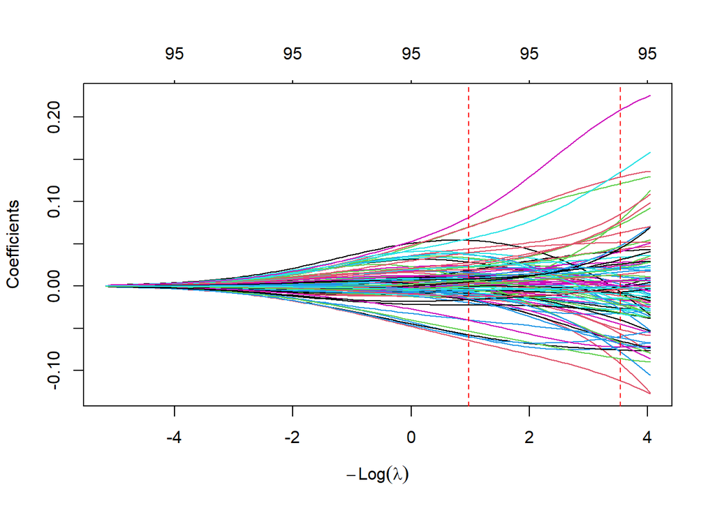

```r
cv.ridge_min <- glmnet(x=xtrain, y=ytrain, alpha=0)

plot(cv.ridge_min, xvar = "lambda")
abline(v = -log(cv.ridge$lambda.min), col = "red", lty = "dashed")
abline(v = -log(cv.ridge$lambda.1se), col = "red", lty = "dashed")
```

## 6.2 Regularization using AmesHosing Data: Data Preparation (Your Turn)

```r
# AmesHousing::make_ames() - processed version of the data
data("ames_raw")
head(ames_raw)
```

```
# A tibble: 6 × 82
  Order PID     `MS SubClass` `MS Zoning` `Lot Frontage` `Lot Area` Street Alley
  <int> <chr>   <chr>         <chr>                <int>      <int> <chr>  <chr>
1     1 052630… 020           RL                     141      31770 Pave   <NA>
2     2 052635… 020           RH                      80      11622 Pave   <NA>
3     3 052635… 020           RL                      81      14267 Pave   <NA>
4     4 052635… 020           RL                      93      11160 Pave   <NA>
5     5 052710… 060           RL                      74      13830 Pave   <NA>
6     6 052710… 060           RL                      78       9978 Pave   <NA>
# ℹ 74 more variables: `Lot Shape` <chr>, `Land Contour` <chr>,
#   Utilities <chr>, `Lot Config` <chr>, `Land Slope` <chr>,
#   Neighborhood <chr>, `Condition 1` <chr>, `Condition 2` <chr>,
#   `Bldg Type` <chr>, `House Style` <chr>, `Overall Qual` <int>,
#   `Overall Cond` <int>, `Year Built` <int>, `Year Remod/Add` <int>,
#   `Roof Style` <chr>, `Roof Matl` <chr>, `Exterior 1st` <chr>,
#   `Exterior 2nd` <chr>, `Mas Vnr Type` <chr>, `Mas Vnr Area` <int>, …
```

```r
set.seed(123)
ames_split <- initial_split(AmesHousing::make_ames(), prop = .7, strata = "Sale_Price")
ames_train <- training(ames_split)
ames_test  <- testing(ames_split)


lm(Sale_Price ~ Gr_Liv_Area + TotRms_AbvGrd, data = ames_train) # show multi colinearity
```

```
Call:
lm(formula = Sale_Price ~ Gr_Liv_Area + TotRms_AbvGrd, data = ames_train)

Coefficients:
  (Intercept)    Gr_Liv_Area  TotRms_AbvGrd
      46845.1          139.2       -11640.4
```

```r
# Create training and testing feature model matrices and response vectors.
# we use model.matrix(...)[, -1] to discard the intercept

ames_train_x <- model.matrix(Sale_Price ~ ., ames_train)[, -1]
ames_train_y <- log(ames_train$Sale_Price)

ames_test_x <- model.matrix(Sale_Price ~ ., ames_test)[, -1]
ames_test_y <- log(ames_test$Sale_Price)

# (ames_train_x)  What is the dimension of of your feature matrix?
dim(ames_train_x)
```

```
[1] 2049  308
```

### 6.2.1 AmesHousing Data, Lasso

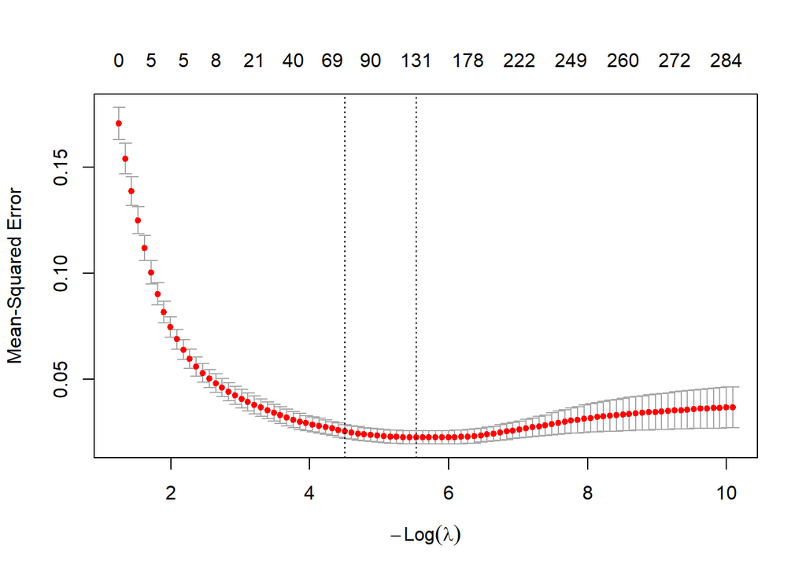

```r
# Apply CV lasso regression to ames data
ames_lasso <- cv.glmnet(x = ames_train_x,  y = ames_train_y,  alpha = 1)
plot(ames_lasso)
```

```r
ames_lasso$lambda.min     # lambda for this min MSE
```

```
[1] 0.003957686
```

```r
ames_lasso$lambda.1se  # lambda for this MSE
```

```
[1] 0.0110125
```

```r
min(ames_lasso$cvm)       # minimum MSE
```

```
[1] 0.02244937
```

```r
ames_lasso$cvm[ames_lasso$lambda == ames_lasso$lambda.1se]  # 1 st.error of min MSE
```

```
[1] 0.02529862
```

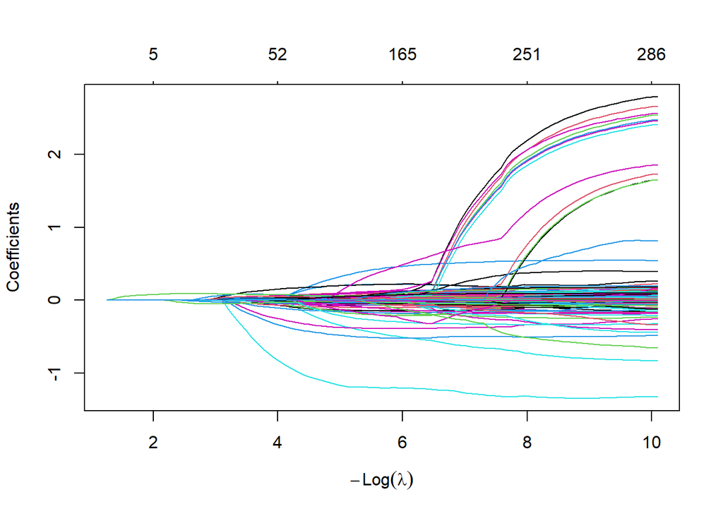

```r
ames_lasso_min <- glmnet(x = ames_train_x, y = ames_train_y, alpha = 1)
plot(ames_lasso_min, xvar = "lambda")
abline(v = log(ames_lasso$lambda.min), col = "red", lty = "dashed")
abline(v = log(ames_lasso$lambda.1se), col = "red", lty = "dashed")
```

### 6.2.2 Regularization using AmesHosing Data, Ridge

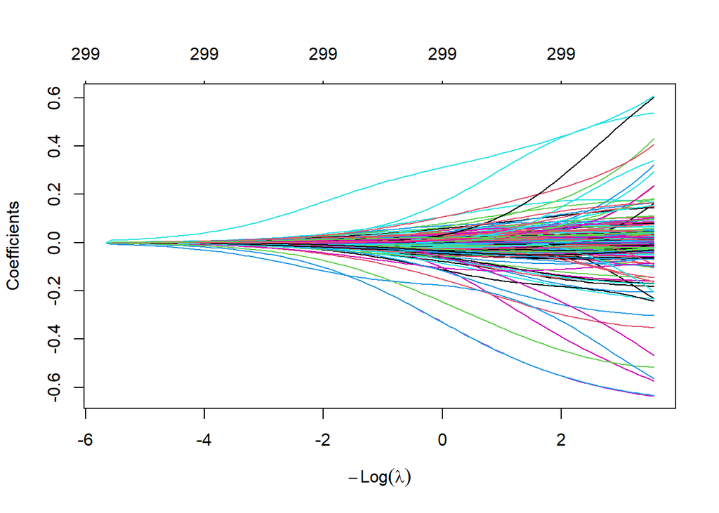

```r
ames_ridge <- glmnet(x = ames_train_x, y = ames_train_y,alpha = 0)

plot(ames_ridge, xvar = "lambda")
```

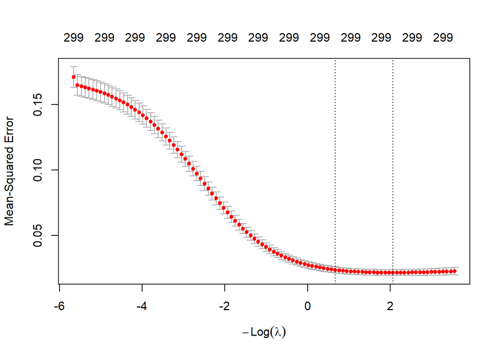

```r
# Apply CV Ridge regression to ames data
ames_ridge <- cv.glmnet(x = ames_train_x, y = ames_train_y,  alpha = 0)

# plot results
plot(ames_ridge)
```

```r
ames_ridge$lambda.min  # lambda for this min MSE
```

```
[1] 0.1266169
```

```r
ames_ridge$lambda.1se  # lambda for this MSE
```

```
[1] 0.5111547
```

```r
ames_ridge$cvm[ames_ridge$lambda == ames_ridge$lambda.min]  # MSE at lambda.min
```

```
[1] 0.02165889
```

```r
ames_ridge$cvm[ames_ridge$lambda == ames_ridge$lambda.1se]  # MSE at lambda.1se
```

```
[1] 0.02374512
```

## 6.3 Regularization - classificationat, Heart Data, Preparation

```r
# Classification model
data  <-  read_sav(here("data", "Heart Data.sav"))

#separate x and y
xdata <-  model.matrix(CHD ~ ., data)[,-1]
ydata <-  as.factor(data$CHD)

# Random split of data
set.seed(340)
itrain <- sample(1:nrow(data), nrow(data)*0.6)
itest <- (-itrain)


#separate into training and test data
xtrain = xdata[itrain,]
ytrain = ydata[itrain]

xtest = xdata[itest,]
ytest = ydata[itest]
```

### 6.3.1 Fitting Lasso, alpha = 1

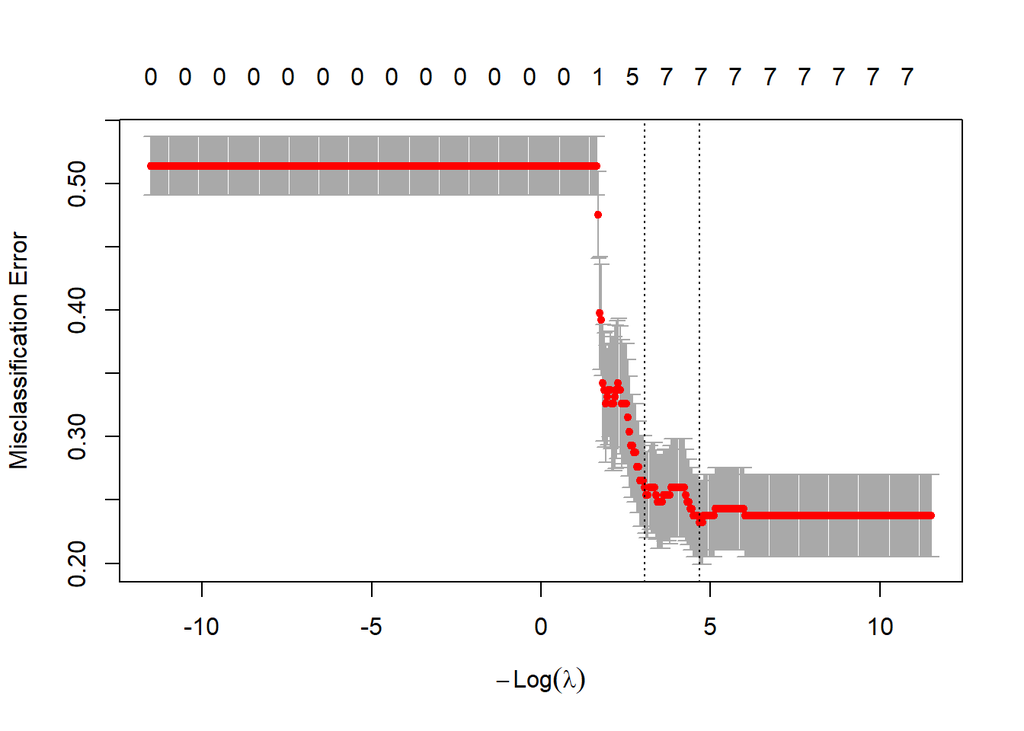

```r
grid = 10^seq(5,-5, length=500) # grid,
set.seed(123)
cv.lasso = cv.glmnet(xtrain, as.factor(ytrain), alpha=1, lambda=grid,
                     nfolds=10, family = "binomial", type.measure = "class")
# type.measure = "response" gives the probabilities
# type.measure = "class" provide 0 and 1 based on predicted probabilities


plot(cv.lasso)
```

```r
cv.lasso
```

```
Call:  cv.glmnet(x = xtrain, y = as.factor(ytrain), lambda = grid, type.measure = "class",      nfolds = 10, alpha = 1, family = "binomial")

Measure: Misclassification Error

     Lambda Index Measure      SE Nonzero
min 0.00925   352  0.2320 0.03303       7
1se 0.04649   317  0.2597 0.03598       5
```

```r
lambda1 <-  cv.lasso$lambda.min
lambda2 <- cv.lasso$lambda.1se

fit.heart <-  glmnet(xtrain, as.factor(ytrain), alpha=1, family ="binomial" )

coef(fit.heart, s=c(lambda1, lambda2))
```

```
8 x 2 sparse Matrix of class "dgCMatrix"
            s=0.009245531 s=0.046487337
(Intercept) -10.595845968   -5.71047188
Age           0.042114036    0.02375579
Sex           1.804613076    1.06693315
ChestPain     0.975971998    0.68011723
RestBP        0.023473315    0.01077111
Chol          0.002605621    .
Fbs          -0.337808460    .
RestECG       0.248731027    0.11007089
```

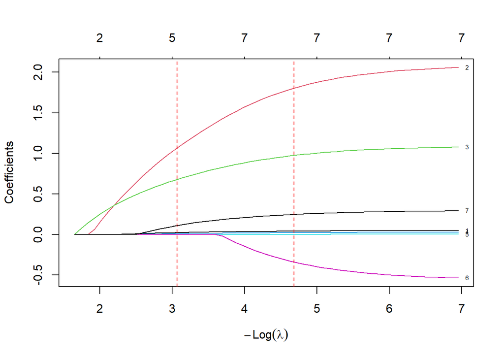

```r
# Plot
plot(fit.heart, xvar = "lambda", label = TRUE)
abline(v = -log(cv.lasso$lambda.min), col = "red", lty = "dashed")
abline(v = -log(cv.lasso$lambda.1se), col = "red", lty = "dashed")
```

```r
lasso.yhat <-  predict(fit.heart, s=lambda2, newx=xtest, type = "class")

ab <- cbind(lasso.yhat,as.data.frame(ytest))
table(ab$ytest, ab$`s=0.04648734`)
```

```
     0  1
  0 55 20
  1  6 41
```

```r
mean(ab$ytest == ab$`s=0.04648734`) #actual == predicted
```

```
[1] 0.7868852
```

# 7 Causal Inference using LASSO

## 7.1 Double Selection: Market entry data

```r
dataset  <-  read.csv(here("data", "mentry.csv")) #line 500

x <- dataset %>% select(-GeoR,-Operators, -Domicile, -Country, -EntryTimes, -dev_operator) %>% as.matrix()
y_vec <- dataset$EntryTimes
d_vec <- dataset$dev_operator


# Now Train Lasso for Entry Times (Y_vec)
cv.lasso.y <- cv.glmnet(x, y_vec, alpha=1)
cv.lasso.y
```

```
Call:  cv.glmnet(x = x, y = y_vec, alpha = 1)

Measure: Mean-Squared Error

    Lambda Index Measure     SE Nonzero
min 0.0130    56   3.777 0.2976      20
1se 0.3707    20   4.038 0.3001       4
```

```r
bestlam.y <- cv.lasso.y$lambda.min
lasso.y <- glmnet(x, y_vec, alpha=1, lambda=bestlam.y)
coef(lasso.y)
```

```
25 x 1 sparse Matrix of class "dgCMatrix"
                          s0
(Intercept)     1.157905e+01
EconR           2.494923e-01
Admin           5.421163e-03
Demographics    1.995758e-02
Geographic      .
HHI             1.164294e-01
Pop_mill        1.544048e-04
GDPcap          .
HDI            -2.305160e+00
PopDen          2.353659e-05
Urbanization    1.309292e-02
GINI           -2.386372e-02
EconGlob       -3.145451e-03
SocialGlob      2.342350e-04
PoliticalGlob  -1.336831e-03
OverallGlob    -5.054870e-02
GIIInput       -5.080423e-02
GIIOutput      -1.803540e-02
GIIOverall      .
PR              .
CL             -2.050372e-01
EthnicFrac     -2.821563e-01
LinguisticFrac  5.168152e-01
ReligiousFrac   7.766845e-01
G3              3.097458e+00
```

```r
# Train Lasso for treatment : Operator type (1 = operator from developed countries, 0= developing countries)
cv.lasso.d <- cv.glmnet(x, d_vec, alpha=1, family="binomial")
cv.lasso.d
```

```
Call:  cv.glmnet(x = x, y = d_vec, alpha = 1, family = "binomial")

Measure: Binomial Deviance

     Lambda Index Measure      SE Nonzero
min 0.00698    37  0.9518 0.06307      17
1se 0.04484    17  1.0131 0.03941       6
```

```r
bestlam.d <- cv.lasso.d$lambda.min
lasso.d <- glmnet(x, d_vec, alpha=1, lambda=bestlam.d, family = "binomial")
coef(lasso.d)
```

```
25 x 1 sparse Matrix of class "dgCMatrix"
                          s0
(Intercept)    -5.2864519834
EconR           .
Admin           0.0482156027
Demographics    0.1616067575
Geographic      0.0525300376
HHI             .
Pop_mill       -0.0005378606
GDPcap          0.0270294783
HDI            -1.5980267076
PopDen          .
Urbanization    0.0056912072
GINI            0.0076990421
EconGlob        0.0138067090
SocialGlob      0.0464999936
PoliticalGlob   0.0176622504
OverallGlob     .
GIIInput        .
GIIOutput       .
GIIOverall      .
PR             -0.0949075419
CL             -0.0155638965
EthnicFrac      0.7220060054
LinguisticFrac -0.5273916720
ReligiousFrac  -0.4226733754
G3              0.6776703235
```

```r
lm(EntryTimes ~ dev_operator + Admin + Demographics + HHI + GDPcap + HDI + GIIInput + LinguisticFrac + ReligiousFrac + G3, data = dataset) %>% tidy() %>% round_df(digits=4)
```

```
# A tibble: 11 × 5
   term           estimate std.error statistic p.value
   <chr>             <dbl>     <dbl>     <dbl>   <dbl>
 1 (Intercept)      9.60      0.835     11.5    0
 2 dev_operator    -0.710     0.230     -3.08   0.0022
 3 Admin            0.0128    0.0063     2.04   0.0418
 4 Demographics     0.0336    0.0176     1.91   0.0566
 5 HHI              0.116     0.0462     2.50   0.0127
 6 GDPcap           0.002     0.0116     0.173  0.863
 7 HDI             -3.54      1.19      -2.98   0.003
 8 GIIInput        -0.0832    0.0181    -4.60   0
 9 LinguisticFrac   0.468     0.448      1.04   0.297
10 ReligiousFrac    0.900     0.503      1.79   0.0743
11 G3               3.22      0.222     14.5    0
```

```r
# Run simple multiple regression without DML to check results later
 x1 <- dataset %>% select(-GeoR,-Operators, -Domicile, -Country, -EconR)
 summary(lm(EntryTimes ~ ., data=x1))
```

```
Call:
lm(formula = EntryTimes ~ ., data = x1)

Residuals:
    Min      1Q  Median      3Q     Max
-6.0178 -1.1964 -0.1081  1.1077  6.3878

Coefficients:
                 Estimate Std. Error t value Pr(>|t|)
(Intercept)    13.5618765  1.5727439   8.623  < 2e-16 ***
dev_operator   -0.6210051  0.2478649  -2.505  0.01265 *
Admin           0.0106311  0.0066009   1.611  0.10810
Demographics    0.0358341  0.0185688   1.930  0.05437 .
Geographic      0.0121111  0.0289312   0.419  0.67573
HHI             0.1092685  0.0527470   2.072  0.03898 *
Pop_mill        0.0001787  0.0007676   0.233  0.81608
GDPcap          0.0026844  0.0127336   0.211  0.83315
HDI            -4.7150826  1.5503731  -3.041  0.00252 **
PopDen          0.0001268  0.0001969   0.644  0.52009
Urbanization    0.0193545  0.0078347   2.470  0.01393 *
GINI           -0.0261868  0.0156916  -1.669  0.09597 .
EconGlob        0.0441152  0.0242956   1.816  0.07019 .
SocialGlob      0.0586197  0.0263480   2.225  0.02668 *
PoliticalGlob   0.0406182  0.0212858   1.908  0.05711 .
OverallGlob    -0.1836298  0.0652897  -2.813  0.00517 **
GIIInput       -0.2071270  0.0749131  -2.765  0.00597 **
GIIOutput      -0.1608819  0.0690553  -2.330  0.02034 *
GIIOverall      0.2817789  0.1373165   2.052  0.04085 *
PR              0.0993715  0.1579939   0.629  0.52975
CL             -0.3628846  0.1953808  -1.857  0.06404 .
EthnicFrac     -0.3244481  0.7225927  -0.449  0.65368
LinguisticFrac  0.6534741  0.6105783   1.070  0.28518
ReligiousFrac   0.7696271  0.5149768   1.494  0.13587
G3              3.1441466  0.2231254  14.091  < 2e-16 ***
---
Signif. codes:  0 '***' 0.001 '**' 0.01 '*' 0.05 '.' 0.1 ' ' 1

Residual standard error: 1.889 on 382 degrees of freedom
Multiple R-squared:  0.6888,    Adjusted R-squared:  0.6692
F-statistic: 35.22 on 24 and 382 DF,  p-value: < 2.2e-16
```

# 8 Double Machine Learning: Process

```r
x <- dataset %>% select(-GeoR,-Operators, -Domicile, -Country, -EconR, -EntryTimes, -dev_operator) %>% as.matrix()
y_vec <- dataset$EntryTimes
d_vec <- dataset$dev_operator

# Divide the sample into training (S1) and estimation sample (S2)
set.seed(123)
S1 <- sample(x=c(1:nrow(x)), size = nrow(x)/2, replace = FALSE) %>% sort()
S2 <- setdiff(c(1:nrow(x)),S1)



# Now Train Lasso for Entry Times (Y_vec)
cv.lasso.y <- cv.glmnet(x[S1,], y_vec[S1], alpha=1)
bestlam.y <- cv.lasso.y$lambda.min
lasso.y <- glmnet(x[S1,], y_vec[S1], alpha=1, lambda=bestlam.y)

# Train Lasso for treatment : Operator type (1 = operator from developed countries, 0= developing countries)
cv.lasso.d <- cv.glmnet(x[S1,], d_vec[S1], alpha=1, family="binomial")
bestlam.d <- cv.lasso.d$lambda.min
lasso.d <- glmnet(x[S1,], d_vec[S1], alpha=1, lambda=bestlam.d, family = "binomial")

# Make prediction in sample S2, estimation sample
predict.y <- predict(lasso.y, newx=x[S2,], s=bestlam.y)
predict.d <- predict(lasso.d, newx=x[S2,], s=bestlam.d, type="response") # predicts probabilities



# Get the residuals
resid.y <- y_vec[S2]-predict.y
resid.d <- d_vec[S2]-predict.d

# DML Estimator

mean(resid.y*resid.d)/mean(resid.d*resid.d)
```

```
[1] -0.4862118
```

```r
lm(resid.y ~ resid.d) %>% tidy()
```

```
# A tibble: 2 × 5
  term        estimate std.error statistic p.value
  <chr>          <dbl>     <dbl>     <dbl>   <dbl>
1 (Intercept)   0.0290     0.137     0.211   0.833
2 resid.d      -0.480      0.352    -1.36    0.175
```

## 8.1 DML function using function to estimate and get cross-fit result

```r
x <- dataset %>% select(-GeoR,-Operators, -Domicile, -Country, -EconR, -EntryTimes, -dev_operator) %>% as.matrix()
y_vec <- dataset$EntryTimes
d_vec <- dataset$dev_operator

# Divide the sample into training (S1) and estimation sample (S2)
set.seed(1278)
S1 <- sample(x=c(1:nrow(x)), size = nrow(x)/2, replace = FALSE) %>% sort()
S2 <- setdiff(c(1:nrow(x)),S1)



DML_estimator <-  function(data, S1, S2) {

# Create x and y matrix

data %>% select(-GeoR,-Operators, -Domicile, -Country, -EconR, -EntryTimes, -dev_operator) %>%
    as.matrix() -> x
y_vec <- data$EntryTimes
d_vec <- data$dev_operator

# Now Train Lasso for Entry Times (Y_vec)
cv.lasso.y <- cv.glmnet(x[S1,], y_vec[S1], alpha=1)
bestlam.y <- cv.lasso.y$lambda.min
lasso.y <- glmnet(x[S1,], y_vec[S1], alpha=1, lambda=bestlam.y)

# Train Lasso for treatment : Operator type (1 = operator from developed countries, 0= developing countries)
cv.lasso.d <- cv.glmnet(x[S1,], d_vec[S1], alpha=1, family="binomial")
bestlam.d <- cv.lasso.d$lambda.min
lasso.d <- glmnet(x[S1,], d_vec[S1], alpha=1, lambda=bestlam.d, family = "binomial")

# Make prediction in sample S2, estimation sample
predict.y <- predict(lasso.y, newx=x[S2,], s=bestlam.y)
predict.d <- predict(lasso.d, newx=x[S2,], s=bestlam.d, type="response") # predicts probabilities



# Get the residuals
resid.y <- y_vec[S2]-predict.y
resid.d <- as.numeric(d_vec[S2])-predict.d

# DML Estimator

mean(resid.y*resid.d)/mean(resid.d*resid.d) %>%
  return(.)
}



#DML_estimator(data=dataset, S1=S1, S2=S2)

DML_crossfit <- function(data, S1, S2){
  est1 <- DML_estimator(data=data, S1=S1, S2=S2)
  est2 <- DML_estimator(data=data, S1=S2, S2=S1)
  data.frame(
    estimate=0.50*est1 + 0.50*est2, est1, est2) %>%
    return(.)
}

DML_crossfit(data=dataset, S1=S1, S2=S2) # could do so with bootstrapping
```

```
    estimate       est1       est2
1 -0.5346617 -0.4866136 -0.5827099
```